# RDA project

JBNU statistics

2021 12 14

## 목적 : 단동 비닐하우스 환기율 및 온습도에 대한 예측모형 구축 및 평가 (반응변수 : 내부CO2)

## 사용모형 : Multiple Linear Regression Model v.s Artificial Neural Network Model (ANN)

## 0. 분석방향

- 내부CO2를 반응변수로, 외부기온, 외부CO2, 외부풍속, 외부일사량, 환기창면적을 독립변수로 하는 선형회귀모형 적합.
- 작물유무에 따라 실험이 수행되었으므로 두 경우에 각각 다른 모형을 적합해보고, 두 데이터세트를 합쳐서 작물유무를 추가 독립변수로 가지는 모형을 또한 적합하여 본다.
- 환기율은 외부기온, 외부풍속, 환기창면적 등에 의해 계산되는 값이다. 이 변수들이 이미 독립변수로 고려되었으므로 환기율은 독립변수에 포함시키지 않는다.
- 고려하는 독립변수들은 모두 어느 정도의 중요도를 가진다고 판단된다. 따라서, 영향력이 큰 변수들을 골라내어 단순화된 모형을 찾는 것이 본 분석의 일차적인 목적은 아닐 수 있다.
- 독립변수들간의 교호작용(혹은 상호작용: interaction effect)이 존재할 수 있다. 하지만 교호작용의 포함은 모형의 해석을 난해하게 만들 수 있다.
- 위 요소들을 종합하여, (1) 가능한 모든 효과를 포함한 모형 (2) 예측성능 혹은 변수선택측도 등의 차원에서 가장 우수한 모형 (3) 모든 독립변수들의 주효과를 포함하되 교호작용은 최소한으로 포함한 모형, 크게 3개의 차원에서 모형을 살펴보고 그 예측성능 및 설명력 등을 비교하여 보겠다.

## 1. Loading data (내부CO2 반응변수)

- 작물있음 데이터에서 외부CO2의 값이 결측치인 경우는 제외하였음.

```r
# setwd("D:/OneDrive - 전북대학교/전북대학교/농림과학원용역/2021")
plantyes <- read.csv("C:/Users/stat/Desktop/작물있음.csv",sep=",",header=T)
plantyes <- plantyes[is.na(plantyes$외부CO2)==FALSE,]
head(plantyes,10)
```

```
##    외부기온 내부기온 내외부기온차 외부상대습도 내부상대습도 내외부상대습도차
## 1      22.9     31.1          8.3         78.7         55.0             23.7
## 2      22.8     29.7          6.9         77.1         58.7             18.4
## 3      23.3     29.7          6.4         75.5         58.4             17.1
## 4      23.6     29.8          6.2         72.9         57.8             15.1
## 5      24.0     30.0          6.0         71.2         56.4             14.8
## 6      25.1     33.3          8.1         66.6         49.6             17.0
## 7      25.9     35.6          9.7         66.0         43.6             22.4
## 8      25.0     34.0          8.9         68.0         44.9             23.1
## 9      25.9     33.7          7.8         65.6         46.4             19.2
## 10     26.8     35.9          9.1         61.8         44.1             17.7
##    외부CO2 내부CO2 내외부CO2차 외부풍속 외부일사량 환기율 환기창면적 작물유무
## 1    469.5   462.0         7.5    1.398      372.7    5.4       0.15      yes
## 2    464.5   459.7         4.8    1.326      309.9    5.0       0.15      yes
## 3    457.5   451.3         6.2    0.835      291.9    4.0       0.15      yes
```

[output cut: 18 more lines]

```r
plantyes$작물유무 <- as.factor(plantyes$작물유무)
plantno <- read.csv("C:/Users/stat/Desktop/작물없음.csv",sep=",",header=T)
head(plantno,10)
```

```
##    외부기온 내부기온 내외부기온차 외부상대습도 내부상대습도 내외부상대습도차
## 1      16.8     27.1         10.3         45.1         39.6              5.5
## 2      17.2     28.3         11.1         42.5         37.6              4.9
## 3      17.6     29.1         11.5         42.9         33.2              9.7
## 4      18.0     30.3         12.4         41.2         32.4              8.8
## 5      17.9     30.6         12.7         37.2         28.8              8.4
## 6      18.0     31.3         13.3         37.4         27.1             10.3
## 7      18.0     31.7         13.7         35.8         25.3             10.5
## 8      18.0     32.0         14.0         38.6         24.4             14.2
## 9      18.3     32.7         14.5         37.0         23.5             13.5
## 10     18.3     32.6         14.3         36.1         22.6             13.5
##    외부CO2 내부CO2 내외부CO2차 외부풍속 외부일사량 환기율 환기창면적 작물유무
## 1    543.5   608.0        64.5    1.576      409.4  0.704       0.04       no
## 2    543.0   580.0        37.0    1.707      442.7  0.756       0.04       no
## 3    522.5   585.5        63.0    1.342      476.5  0.634       0.04       no
```

[output cut: 18 more lines]

```r
plantno$작물유무 <- as.factor(plantno$작물유무)
plant <- rbind(plantno,plantyes)
```

## Multiple Linear Regression Model

## 2. 작물유무에 따라 데이터를 나누어서 분석 실시

### 2.1 작물이 없을 때

#### Multiple Linear Regression Model

- 먼저 변수들 간의 상관관계를 파악하기 위해 상관분석을 실시한다.

```r
ex1 <- plantno[,c(8,1,7,10,11,13)]
head(ex1)
```

```
##   내부CO2 외부기온 외부CO2 외부풍속 외부일사량 환기창면적
## 1   608.0     16.8   543.5    1.576      409.4       0.04
## 2   580.0     17.2   543.0    1.707      442.7       0.04
## 3   585.5     17.6   522.5    1.342      476.5       0.04
## 4   593.5     18.0   543.0    1.802      505.7       0.04
## 5   590.5     17.9   520.5    2.583      536.0       0.04
## 6   585.5     18.0   529.5    3.660      564.9       0.04
```

```r
cor(ex1)
```

```
##                내부CO2      외부기온       외부CO2      외부풍속    외부일사량
## 내부CO2     1.00000000 -3.248325e-02  9.330146e-02 -9.939070e-02 -3.290872e-02
## 외부기온   -0.03248325  1.000000e+00 -3.112018e-01  3.063871e-01  3.274643e-01
## 외부CO2     0.09330146 -3.112018e-01  1.000000e+00 -5.914228e-01 -4.942462e-02
## 외부풍속   -0.09939070  3.063871e-01 -5.914228e-01  1.000000e+00  4.772916e-02
## 외부일사량 -0.03290872  3.274643e-01 -4.942462e-02  4.772916e-02  1.000000e+00
## 환기창면적 -0.86765569 -9.044468e-20  1.450984e-19  3.715441e-20 -5.089237e-20
##               환기창면적
## 내부CO2    -8.676557e-01
## 외부기온   -9.044468e-20
## 외부CO2     1.450984e-19
## 외부풍속    3.715441e-20
## 외부일사량 -5.089237e-20
## 환기창면적  1.000000e+00
```

- 산점도행렬과 상관계수그림을 그리면 다음과 같다.

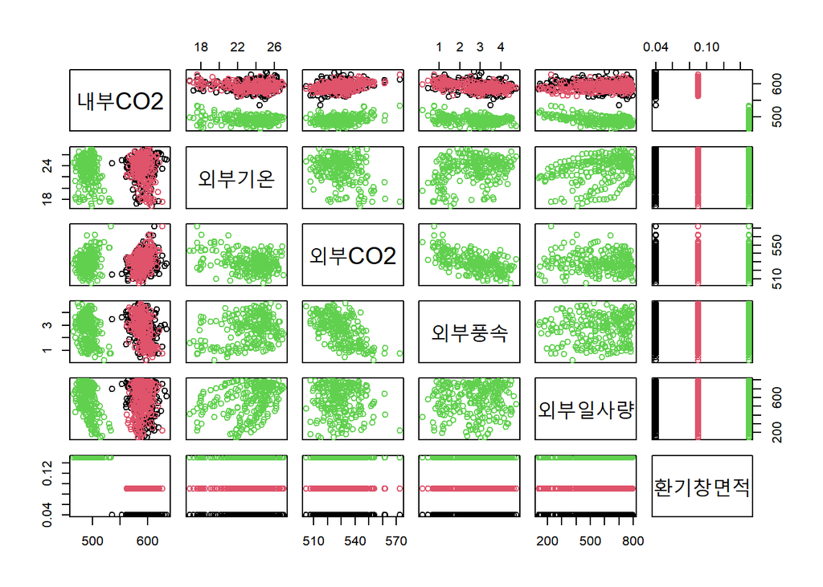

```r
pairs(ex1,col=factor(ex1$환기창면적))
```

- 설명변수와 반응변수간의 뚜렷한 상관성이 관측되지 않는다. 단, 환기창 면적이 커지면 내부 CO2가 줄어드는 것으로 보이기는 한다. 다만, 0.04, 0.09일 때 하나의 그룹 0.15일 때 또 하나의 그룹을 이루고 있는데 해석이 쉽지는 않다. 환기창면적이 특정 수준에 이르러야 내부 CO2 가 떨어지는 것으로 해석할 수도 있고, 실험조건을 다시 확인해야 할 수도 있을 것이다.
- 환기창면적과 다른 주효과들간의 뚜렷한 교호작용이 관측되지는 않는다.
- 외부풍속은 약하지만 내부CO2와 음의 상관을 보이는 것으로 생각된다. 외부 CO2는 양의 상관을 약하게 가진다.

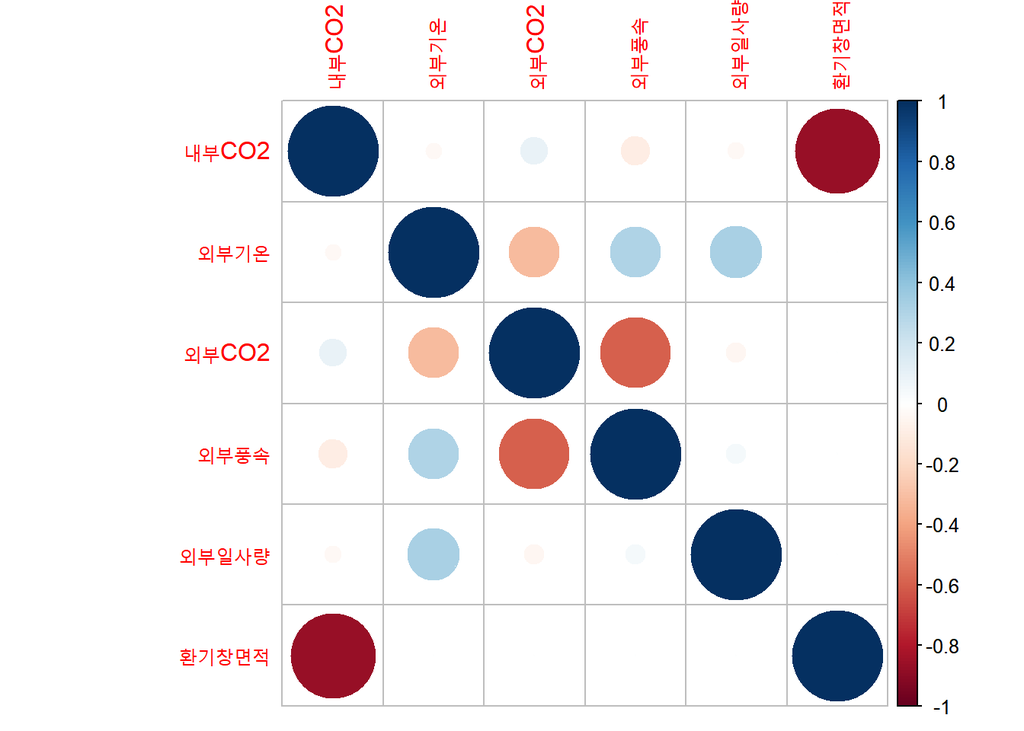

```r
library(corrplot)
corrplot(cor(ex1))
```

- 그리고 각 변수에 대한 기초통계량은 다음과 같이 계산된다.

```r
library(psych)
describe(ex1)
```

```
##            vars   n   mean     sd median trimmed    mad    min    max  range
## 내부CO2       1 735 558.49  49.02 582.50  561.63  29.65 464.50 635.50 171.00
## 외부기온      2 735  23.39   2.30  24.00   23.66   1.93  16.80  27.00  10.20
## 외부CO2       3 735 529.40  11.13 528.00  529.01  11.12 504.50 572.50  68.00
## 외부풍속      4 735   2.71   1.08   2.87    2.73   1.29   0.21   4.74   4.54
## 외부일사량    5 735 568.60 171.31 601.10  584.32 191.40 143.00 795.20 652.20
## 환기창면적    6 735   0.09   0.04   0.09    0.09   0.07   0.04   0.15   0.11
##             skew kurtosis   se
## 내부CO2    -0.60    -1.36 1.81
## 외부기온   -0.98     0.30 0.08
## 외부CO2     0.47     0.44 0.41
## 외부풍속   -0.26    -0.99 0.04
## 외부일사량 -0.63    -0.61 6.32
## 환기창면적  0.11    -1.50 0.00
```

- 내부CO2를 반응변수로 하여 각 변수의 주효과와 모든 가능한 교호작용을 고려한 다중선형회귀모형을 적합하면 다음과 같다.
- 모든 교호작용을 함께 고려한 것은, 사전분석 결과 환기창면적과 다른 변수들과의 교호작용 뿐 아니라 다른 효과들도 비교적 유의미하게 관측되었기 때문이다.

```r
m_no <- lm(내부CO2~(외부기온+외부CO2+외부풍속+외부일사량+환기창면적)^2,data=plantno)
summary(m_no)
```

```
##
## Call:
## lm(formula = 내부CO2 ~ (외부기온 + 외부CO2 + 외부풍속 + 외부일사량 +
##     환기창면적)^2, data = plantno)
##
## Residuals:
##     Min      1Q  Median      3Q     Max
## -67.370 -17.615  -6.845  22.399  57.024
##
## Coefficients:
##                         Estimate Std. Error t value Pr(>|t|)
## (Intercept)           -1.007e+01  5.469e+02  -0.018    0.985
## 외부기온               1.921e+01  2.724e+01   0.705    0.481
## 외부CO2                1.241e+00  9.823e-01   1.264    0.207
## 외부풍속               6.259e+01  5.282e+01   1.185    0.236
## 외부일사량            -2.748e-01  3.544e-01  -0.775    0.438
## 환기창면적            -1.765e+02  1.256e+03  -0.140    0.888
## 외부기온:외부CO2      -3.634e-02  4.983e-02  -0.729    0.466
## 외부기온:외부풍속     -6.518e-01  5.198e-01  -1.254    0.210
## 외부기온:외부일사량    4.751e-03  3.177e-03   1.495    0.135
## 외부기온:환기창면적   -6.064e+00  9.612e+00  -0.631    0.528
## 외부CO2:외부풍속      -9.412e-02  9.355e-02  -1.006    0.315
## 외부CO2:외부일사량     3.407e-04  6.372e-04   0.535    0.593
## 외부CO2:환기창면적    -1.032e+00  2.211e+00  -0.467    0.641
## 외부풍속:외부일사량   -2.269e-03  6.575e-03  -0.345    0.730
## 외부풍속:환기창면적    1.192e+01  2.284e+01   0.522    0.602
## 외부일사량:환기창면적 -1.980e-01  1.210e-01  -1.636    0.102
##
## Residual standard error: 23.81 on 719 degrees of freedom
## Multiple R-squared:  0.7689, Adjusted R-squared:  0.7641
## F-statistic: 159.5 on 15 and 719 DF,  p-value: < 2.2e-16
```

- 모형적합 결과 모든 주효과와 교호작용이 유의수준 0.05에서 유의미하지 않았다. 그러므로 변수선택을 통해 유의미한 항을 다시 선택하는 과정이 필요하다고 보여진다.
- 모든 교호작용이 유의미하지는 않지만 이들 중 그래도 가장 중요하다고 판단되는 1가지를 선택한다면 t 통계량의 절대값이 가장 큰 외부일사량과 환기창면적 사이의 교호작용을 고를 수 있다.
- 조정된 결정계수의 값이 $R^2_{adj}=0.7641$이다. 주어진 모형의 설명력이 다른 항목의 결과와 비교하면 그리 높아보이지 않으나 설명력을 어느 정도 갖추고 있다.

#### Best subset selection

- 여러 측도들을 이용하여 모형에 포함될 변수를 적절히 선택해 보도록 하겠다.

```r
library(leaps)
ms0 <- regsubsets(내부CO2~(외부기온+외부CO2+외부풍속+외부일사량+환기창면적)^2,data=plantno,nvmax=15)
ms0.summary <- summary(ms0)
ms0.summary
```

```
## Subset selection object
## Call: regsubsets.formula(내부CO2 ~ (외부기온 + 외부CO2 + 외부풍속 +
##     외부일사량 + 환기창면적)^2, data = plantno, nvmax = 15)
## 15 Variables  (and intercept)
##                       Forced in Forced out
## 외부기온                  FALSE      FALSE
## 외부CO2                   FALSE      FALSE
## 외부풍속                  FALSE      FALSE
## 외부일사량                FALSE      FALSE
## 환기창면적                FALSE      FALSE
## 외부기온:외부CO2          FALSE      FALSE
## 외부기온:외부풍속         FALSE      FALSE
## 외부기온:외부일사량       FALSE      FALSE
## 외부기온:환기창면적       FALSE      FALSE
## 외부CO2:외부풍속          FALSE      FALSE
```

[output cut: 71 more lines]

```r
par(mfrow=c(2,2))
# RSS=SSE
plot(ms0.summary$rss,xlab="Number of Variables",ylab="RSS",type="l")
# Adj R^2
plot(ms0.summary$adjr2,xlab="Number of Variables",ylab="Adjusted RSq",type="l")
which.max(ms0.summary$adjr2)
```

```
## [1] 8
```

```r
points(which.max(ms0.summary$adjr2)
,ms0.summary$adjr2[which.max(ms0.summary$adjr2)
], col="red",cex=2,pch=20)
# Cp
plot(ms0.summary$cp,xlab="Number of Variables",ylab="Cp",type='l')
which.min(ms0.summary$cp)
```

```
## [1] 5
```

```r
points(which.min(ms0.summary$cp)
,ms0.summary$cp[which.min(ms0.summary$cp)
],col="red",cex=2,pch=20)
# BIC
plot(ms0.summary$bic,xlab="Number of Variables",ylab="BIC",type='l')
which.min(ms0.summary$bic)
```

```
## [1] 3
```

```r
points(which.min(ms0.summary$bic)
,ms0.summary$bic[which.min(ms0.summary$bic)
],col="red",cex=2,pch=20)
```

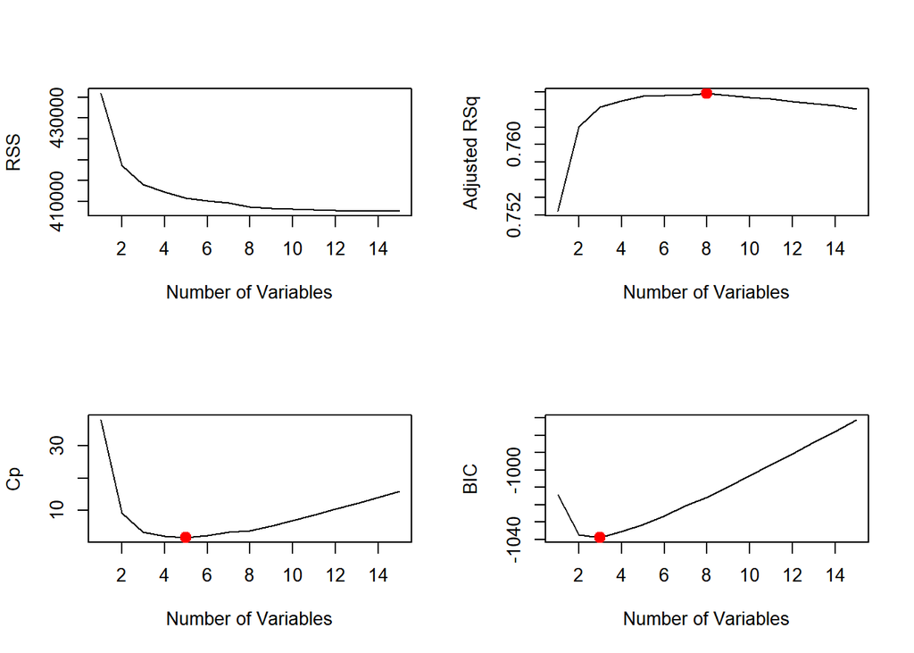

```r
par(mfrow=c(1,1))
```

- 분석결과 $R_{adj}^2$는 변수의 개수 8인 모형, $Cp$는 변수의 개수 5인 모형, 그리고 $BIC$는 변수의 개수 3인 모형을 최적으로 판단하고 있다. 이들 중 가장 간단한 변수의 개수 3인 모형을 선택하도록 한다. 복잡한 모형이 항상 바람직한 결과를 주지는 않으며 단순한 모형도 설명력이 높은 경우가 많기 때문이다.

```r
summary(lm(내부CO2~외부CO2+외부CO2*환기창면적+외부풍속*외부일사량,data=plantno))
```

```
##
## Call:
## lm(formula = 내부CO2 ~ 외부CO2 + 외부CO2 * 환기창면적 + 외부풍속 *
##     외부일사량, data = plantno)
##
## Residuals:
##     Min      1Q  Median      3Q     Max
## -65.167 -17.787  -6.547  22.727  57.691
##
## Coefficients:
##                       Estimate Std. Error t value Pr(>|t|)
## (Intercept)          4.691e+02  1.031e+02   4.548 6.34e-06 ***
## 외부CO2              3.487e-01  1.915e-01   1.821   0.0691 .
## 환기창면적          -3.238e+02  9.306e+02  -0.348   0.7280
## 외부풍속            -9.383e-01  3.077e+00  -0.305   0.7605
## 외부일사량           2.122e-03  1.445e-02   0.147   0.8833
## 외부CO2:환기창면적  -1.174e+00  1.757e+00  -0.668   0.5044
## 외부풍속:외부일사량 -3.663e-03  5.005e-03  -0.732   0.4644
## ---
## Signif. codes:  0 '***' 0.001 '**' 0.01 '*' 0.05 '.' 0.1 ' ' 1
##
## Residual standard error: 23.83 on 728 degrees of freedom
## Multiple R-squared:  0.7656, Adjusted R-squared:  0.7637
## F-statistic: 396.3 on 6 and 728 DF,  p-value: < 2.2e-16
```

#### 교차타당검증에 의한 모형 비교

- 지금부터는 train:test=7:3 으로 데이터를 나누어서 몇 개의 후보 모형들의 test RMSE를 계산하여 보겠다. 이 값이 작을수록 예측력이 우수한 모형이라고 볼 수 있다.
- 먼저 데이터를 임의로 train:test=7:3 의 비율로 나눈다. train data는 모형구축 시, test data는 구축된 모형을 평가 시 사용한다.
- 모형에 대한 성능은 test RMSE와 SSE/SST를 바탕으로 실시하며, 두가지 기준 모두 그 값이 작을수록 모형의 예측력이 우수하다고 판단하면 된다.
- $RMSE=\sqrt{{\frac {1}{n} \sum_{i=1}^{n} (y_{i}-\hat{y_{i}})^{2}}}$
- $SSE/SST=\frac {\sum_{i=1}^{n} (y_{i}-\hat{y_{i}})^{2}} {\sum_{i=1}^{n} (y_{i}-\bar{y})^{2}}$

```r
set.seed(5790)
train.index <- sample(1:nrow(plantno), round(nrow(plantno)*7/10), replace=F)
ex1_train <- plantno[train.index,]
ex1_test <- plantno[-train.index,]
```

```r
# model1 : 모든 주효과 및 교호작용을 포함한 모형
m0 <- lm(내부CO2~(외부기온+외부CO2+외부풍속+외부일사량+환기창면적)^2,data=ex1_train)
y_hat0 <- predict(m0,ex1_test)
RMSE0 <- sqrt(mean((ex1_test$내부CO2-y_hat0)^2))
SSE0 <- sum((ex1_test$내부CO2-y_hat0)^2)
SST0 <- sum((ex1_test$내부CO2-mean(ex1_test$내부CO2))^2)
result0 <- data.frame(ex1_test$내부CO2, y_hat0, ex1_test$내부CO2-y_hat0)
colnames(result0) <- c('y','yhat','y-yhat')
RMSE0 # test RMSE
```

```
## [1] 23.3893
```

```r
SSE0/SST0 # SSE/SST
```

```
## [1] 0.2317942
```

```r
head(result0,12)
```

```
##        y     yhat     y-yhat
## 3  585.5 604.8151 -19.315072
## 5  590.5 603.0629 -12.562886
## 7  583.0 602.8312 -19.831228
## 10 592.0 601.7996  -9.799611
## 12 573.0 598.8067 -25.806743
## 17 595.5 602.9574  -7.457425
## 20 597.5 601.8480  -4.348008
## 24 598.5 606.9845  -8.484456
## 33 583.5 606.5303 -23.030324
## 51 606.5 610.2745  -3.774547
## 60 605.0 613.7648  -8.764822
## 62 604.5 612.5217  -8.021717
```

```r
# model2 : Adj R^2, Cp, BIC 등의 기준을 바탕으로 선택된 모형 (교호작용이 있는 경우는 주효과 포함)
m0 <- lm(내부CO2~외부CO2+외부CO2*환기창면적+외부풍속*외부일사량,data=ex1_train)
y_hat0 <- predict(m0,ex1_test)
RMSE1 <- sqrt(mean((ex1_test$내부CO2-y_hat0)^2))
SSE1 <- sum((ex1_test$내부CO2-y_hat0)^2)
SST1 <- sum((ex1_test$내부CO2-mean(ex1_test$내부CO2))^2)
result1 <- data.frame(ex1_test$내부CO2, y_hat0, ex1_test$내부CO2-y_hat0)
colnames(result1) <- c('y','yhat','y-yhat')
RMSE1 # test RMSE
```

```
## [1] 23.38021
```

```r
SSE1/SST1 # SSE/SST
```

```
## [1] 0.2316142
```

```r
head(result1,12)
```

```
##        y     yhat     y-yhat
## 3  585.5 612.7683 -27.268349
## 5  590.5 608.3621 -17.862052
## 7  583.0 607.5773 -24.577345
## 10 592.0 606.9108 -14.910779
## 12 573.0 602.7038 -29.703752
## 17 595.5 605.9223 -10.422276
## 20 597.5 602.2534  -4.753353
## 24 598.5 606.0123  -7.512290
## 33 583.5 607.2059 -23.705913
## 51 606.5 615.9412  -9.441217
## 60 605.0 616.2062 -11.206238
## 62 604.5 614.2731  -9.773127
```

```r
# model3 : 모든 주효과와 가장 중요한 교호작용 1가지를 포함한 모형 (환기창면적과 외부일사량 사이의 교호작용)
m0 <- lm(내부CO2~외부기온+외부CO2+외부풍속+외부일사량+환기창면적+환기창면적*외부일사량,data=ex1_train)
y_hat0 <- predict(m0,ex1_test)
RMSE2 <- sqrt(mean((ex1_test$내부CO2-y_hat0)^2))
SSE2 <- sum((ex1_test$내부CO2-y_hat0)^2)
SST2 <- sum((ex1_test$내부CO2-mean(ex1_test$내부CO2))^2)
result2 <- data.frame(ex1_test$내부CO2, y_hat0, ex1_test$내부CO2-y_hat0)
colnames(result2) <- c('y','yhat','y-yhat')
RMSE2 # test RMSE
```

```
## [1] 23.37367
```

```r
SSE2/SST2 # SSE/SST
```

```
## [1] 0.2314846
```

```r
head(result2,12)
```

```
##        y     yhat     y-yhat
## 3  585.5 609.2208 -23.720766
## 5  590.5 605.1186 -14.618557
## 7  583.0 605.2963 -22.296347
## 10 592.0 605.9938 -13.993763
## 12 573.0 601.7298 -28.729799
## 17 595.5 607.9449 -12.444862
## 20 597.5 604.0960  -6.596007
## 24 598.5 608.8307 -10.330736
## 33 583.5 609.2105 -25.710453
## 51 606.5 612.9399  -6.439871
## 60 605.0 616.8045 -11.804548
## 62 604.5 615.2805 -10.780489
```

- 결과적으로 3가지 모형들 중 모든 주효과와 가장 중요한 교호작용 1가지(환기창면적과 외부일사량)를 포함한 모형이 가장 우수하였다. 모형의 오차들 차이가 매우 미미하므로, 가장 단순한 모형을 고려하는 것이 좋을 것이다.
- 기술하지는 않았으나 주효과만을 고려한 모형을 생각하는 것도 좋을 것 같다.
- `:`표시는 교호작용을 의미함.
- model1 : 모든 주효과 및 교호작용을 포함한 모형
  - 반응변수 : 내부CO2
  - 설명변수 : 외부기온, 외부CO2, 외부풍속, 외부일사량, 환기창면적, 외부기온:외부CO2, 외부기온:외부풍속, 외부기온:외부일사량, 외부기온:환기창면적, 외부CO2:외부풍속, 외부CO2:외부일사량, 외부CO2:환기창면적, 외부풍속:외부일사량, 외부풍속:환기창면적, 외부일사량:환기창면적
  - RMSE=23.3893, SSE/SST=0.2318
- model2 : Adj R^2, Cp, BIC 등의 기준을 바탕으로 선택된 모형 (교호작용이 있는 경우는 주효과 포함)
  - 반응변수 : 내부CO2
  - 설명변수 : 외부CO2, 외부CO2:환기창면적, 외부풍속:외부일사량
  - RMSE=23.3802, SSE/SST=0.2316
- model3 : 모든 주효과와 가장 중요한 교호작용 1가지를 포함한 모형 (환기창면적과 외부일사량 사이의 교호작용)
  - 반응변수 : 내부CO2
  - 설명변수 : 외부기온, 외부CO2, 외부풍속, 외부일사량, 환기창면적, 환기창면적:외부일사량
  - RMSE=23.3737, SSE/SST=0.2315

#### 아래는 세 모형에 대한 데이터 전체 적합결과이다.

#### 1. model1

```r
summary(lm(내부CO2~(외부기온+외부CO2+외부풍속+외부일사량+환기창면적)^2,data=plantno) )
```

```
##
## Call:
## lm(formula = 내부CO2 ~ (외부기온 + 외부CO2 + 외부풍속 + 외부일사량 +
##     환기창면적)^2, data = plantno)
##
## Residuals:
##     Min      1Q  Median      3Q     Max
## -67.370 -17.615  -6.845  22.399  57.024
##
## Coefficients:
##                         Estimate Std. Error t value Pr(>|t|)
## (Intercept)           -1.007e+01  5.469e+02  -0.018    0.985
## 외부기온               1.921e+01  2.724e+01   0.705    0.481
## 외부CO2                1.241e+00  9.823e-01   1.264    0.207
## 외부풍속               6.259e+01  5.282e+01   1.185    0.236
## 외부일사량            -2.748e-01  3.544e-01  -0.775    0.438
## 환기창면적            -1.765e+02  1.256e+03  -0.140    0.888
## 외부기온:외부CO2      -3.634e-02  4.983e-02  -0.729    0.466
## 외부기온:외부풍속     -6.518e-01  5.198e-01  -1.254    0.210
## 외부기온:외부일사량    4.751e-03  3.177e-03   1.495    0.135
## 외부기온:환기창면적   -6.064e+00  9.612e+00  -0.631    0.528
## 외부CO2:외부풍속      -9.412e-02  9.355e-02  -1.006    0.315
## 외부CO2:외부일사량     3.407e-04  6.372e-04   0.535    0.593
## 외부CO2:환기창면적    -1.032e+00  2.211e+00  -0.467    0.641
## 외부풍속:외부일사량   -2.269e-03  6.575e-03  -0.345    0.730
## 외부풍속:환기창면적    1.192e+01  2.284e+01   0.522    0.602
## 외부일사량:환기창면적 -1.980e-01  1.210e-01  -1.636    0.102
##
## Residual standard error: 23.81 on 719 degrees of freedom
## Multiple R-squared:  0.7689, Adjusted R-squared:  0.7641
## F-statistic: 159.5 on 15 and 719 DF,  p-value: < 2.2e-16
```

#### 2. model2

```r
summary(lm(내부CO2~외부CO2+외부CO2*환기창면적+외부풍속*외부일사량,data=plantno) )
```

```
##
## Call:
## lm(formula = 내부CO2 ~ 외부CO2 + 외부CO2 * 환기창면적 + 외부풍속 *
##     외부일사량, data = plantno)
##
## Residuals:
##     Min      1Q  Median      3Q     Max
## -65.167 -17.787  -6.547  22.727  57.691
##
## Coefficients:
##                       Estimate Std. Error t value Pr(>|t|)
## (Intercept)          4.691e+02  1.031e+02   4.548 6.34e-06 ***
## 외부CO2              3.487e-01  1.915e-01   1.821   0.0691 .
## 환기창면적          -3.238e+02  9.306e+02  -0.348   0.7280
## 외부풍속            -9.383e-01  3.077e+00  -0.305   0.7605
## 외부일사량           2.122e-03  1.445e-02   0.147   0.8833
## 외부CO2:환기창면적  -1.174e+00  1.757e+00  -0.668   0.5044
## 외부풍속:외부일사량 -3.663e-03  5.005e-03  -0.732   0.4644
## ---
## Signif. codes:  0 '***' 0.001 '**' 0.01 '*' 0.05 '.' 0.1 ' ' 1
##
## Residual standard error: 23.83 on 728 degrees of freedom
## Multiple R-squared:  0.7656, Adjusted R-squared:  0.7637
## F-statistic: 396.3 on 6 and 728 DF,  p-value: < 2.2e-16
```

#### 3. model3

```r
summary(lm(내부CO2~외부기온+외부CO2+외부풍속+외부일사량+환기창면적+환기창면적*외부일사량,data=plantno) )
```

```
##
## Call:
## lm(formula = 내부CO2 ~ 외부기온 + 외부CO2 + 외부풍속 + 외부일사량 +
##     환기창면적 + 환기창면적 * 외부일사량, data = plantno)
##
## Residuals:
##     Min      1Q  Median      3Q     Max
## -67.915 -17.794  -6.561  22.540  57.497
##
## Coefficients:
##                         Estimate Std. Error t value Pr(>|t|)
## (Intercept)            511.46767   56.76645   9.010  < 2e-16 ***
## 외부기온                 0.36034    0.43161   0.835  0.40406
## 외부CO2                  0.24403    0.09927   2.458  0.01419 *
## 외부풍속                -3.20224    1.02575  -3.122  0.00187 **
## 외부일사량               0.01106    0.01194   0.926  0.35450
## 환기창면적            -821.39768   67.64817 -12.142  < 2e-16 ***
## 외부일사량:환기창면적   -0.21769    0.11392  -1.911  0.05641 .
## ---
## Signif. codes:  0 '***' 0.001 '**' 0.01 '*' 0.05 '.' 0.1 ' ' 1
##
## Residual standard error: 23.78 on 728 degrees of freedom
## Multiple R-squared:  0.7667, Adjusted R-squared:  0.7647
## F-statistic: 398.7 on 6 and 728 DF,  p-value: < 2.2e-16
```

#### 해석

- 전체적으로 비슷한 설명력을 보인다.
- 외부기온과 외부CO2는 양의, 외부풍속은 음의 연관성을 내부CO2와 가지는 것으로 보인다.

### 2.2 작물이 있을 때

#### Multiple Linear Regression Model

- 먼저 변수들 간의 상관관계를 파악하기 위해 상관분석을 실시한다.

```r
ex1 <- plantyes[,c(8,1,7,10,11,13)]
head(ex1)
```

```
##   내부CO2 외부기온 외부CO2 외부풍속 외부일사량 환기창면적
## 1   462.0     22.9   469.5    1.398      372.7       0.15
## 2   459.7     22.8   464.5    1.326      309.9       0.15
## 3   451.3     23.3   457.5    0.835      291.9       0.15
## 4   445.7     23.6   453.0    0.943      297.5       0.15
## 5   441.7     24.0   447.5    1.481      335.4       0.15
## 6   440.0     25.1   447.0    1.132      549.7       0.15
```

```r
cor(ex1)
```

```
##                 내부CO2    외부기온     외부CO2    외부풍속   외부일사량
## 내부CO2     1.000000000 -0.24025438  0.47487406 -0.21125322  0.005474763
## 외부기온   -0.240254376  1.00000000 -0.34584154  0.12445561  0.473237433
## 외부CO2     0.474874058 -0.34584154  1.00000000 -0.03373841  0.004954940
## 외부풍속   -0.211253224  0.12445561 -0.03373841  1.00000000  0.012479390
## 외부일사량  0.005474763  0.47323743  0.00495494  0.01247939  1.000000000
## 환기창면적 -0.243066151 -0.08617862  0.09690856  0.10718424 -0.019793616
##             환기창면적
## 내부CO2    -0.24306615
## 외부기온   -0.08617862
## 외부CO2     0.09690856
## 외부풍속    0.10718424
## 외부일사량 -0.01979362
## 환기창면적  1.00000000
```

- 산점도행렬과 상관계수그림을 그리면 다음과 같다.

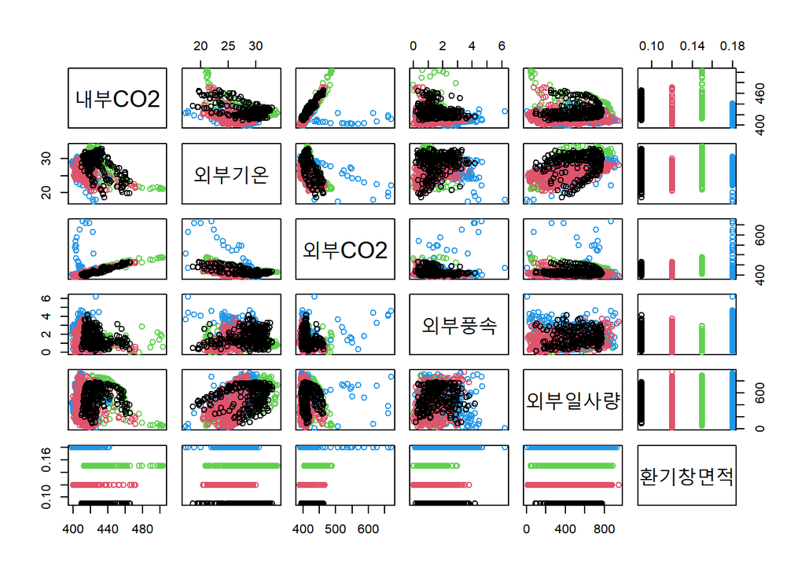

```r
pairs(ex1,col=factor(ex1$환기창면적))
```

- 환기창면적과 다른 주효과들간의 뚜렷한 교호작용이 관측되지는 않는다.
- 작물이 없을 때와 비교할 때 연관성이 다소 명확하다. 특히, 외부 CO2와의 양의 상관성이 보이고, 외부기온과는 음의 상관성이 다소 뚜렷하게 보인다. 단, 환기창 면적이 0.18일때는 설명변수와 반응변수간의 연관성이 완전히 다른 패턴을 보이고 있어 실험조건/데이터수집 등을 살펴볼 필요가 있을 수 있다.

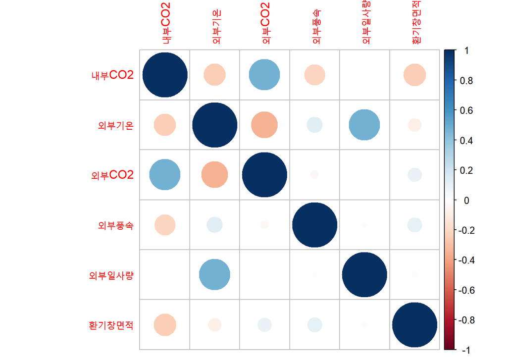

```r
library(corrplot)
corrplot(cor(ex1))
```

- 그리고 각 변수에 대한 기초통계량은 다음과 같이 계산된다.

```r
library(psych)
describe(ex1)
```

```
##            vars    n   mean     sd median trimmed    mad    min    max  range
## 내부CO2       1 1055 419.45  14.70 416.30  417.26  11.27 398.30 504.00 105.70
## 외부기온      2 1055  26.91   2.99  26.90   26.94   3.26  17.30  33.90  16.60
## 외부CO2       3 1055 414.52  25.67 409.00  410.10  11.12 389.50 669.50 280.00
## 외부풍속      4 1055   1.50   0.92   1.30    1.41   0.83   0.00   6.22   6.21
## 외부일사량    5 1055 459.27 225.19 459.20  460.76 275.02  10.04 950.00 939.96
## 환기창면적    6 1055   0.13   0.03   0.12    0.13   0.04   0.09   0.18   0.09
##             skew kurtosis   se
## 내부CO2     1.99     6.07 0.45
## 외부기온   -0.12    -0.42 0.09
## 외부CO2     5.09    37.41 0.79
## 외부풍속    0.97     0.80 0.03
## 외부일사량 -0.02    -1.02 6.93
## 환기창면적  0.12    -1.38 0.00
```

- 내부CO2를 반응변수로 하여 각 변수의 주효과와 모든 가능한 교호작용을 고려한 다중선형회귀모형을 적합하면 다음과 같다.
- 작물이 없을 때와 마찬가지로 모든 교호작용을 함께 고려한 것은, 사전분석 결과 환기창면적과 다른 변수들과의 교호작용 뿐 아니라 다른 효과들도 비교적 유의미하게 관측되었기 때문이다.

```r
m_yes <- lm(내부CO2~(외부기온+외부CO2+외부풍속+외부일사량+환기창면적)^2,data=plantyes)
summary(m_yes)
```

```
##
## Call:
## lm(formula = 내부CO2 ~ (외부기온 + 외부CO2 + 외부풍속 + 외부일사량 +
##     환기창면적)^2, data = plantyes)
##
## Residuals:
##     Min      1Q  Median      3Q     Max
## -30.431  -3.477  -0.534   2.837  38.516
##
## Coefficients:
##                         Estimate Std. Error t value Pr(>|t|)
## (Intercept)           -5.670e+02  5.570e+01 -10.180  < 2e-16 ***
## 외부기온              -1.489e+00  2.005e+00  -0.742   0.4580
## 외부CO2                2.201e+00  1.242e-01  17.727  < 2e-16 ***
## 외부풍속               3.640e+01  5.802e+00   6.274 5.15e-10 ***
## 외부일사량             2.476e-03  2.566e-02   0.096   0.9231
## 환기창면적             5.790e+03  1.969e+02  29.410  < 2e-16 ***
## 외부기온:외부CO2       1.084e-02  4.661e-03   2.325   0.0203 *
## 외부기온:외부풍속     -4.734e-01  1.057e-01  -4.477 8.40e-06 ***
## 외부기온:외부일사량    3.985e-03  3.801e-04  10.484  < 2e-16 ***
## 외부기온:환기창면적   -3.153e+01  2.720e+00 -11.594  < 2e-16 ***
## 외부CO2:외부풍속      -4.456e-02  9.322e-03  -4.780 2.00e-06 ***
## 외부CO2:외부일사량    -2.756e-04  4.796e-05  -5.747 1.19e-08 ***
## 외부CO2:환기창면적    -1.200e+01  3.767e-01 -31.860  < 2e-16 ***
## 외부풍속:외부일사량    2.322e-03  1.178e-03   1.971   0.0490 *
## 외부풍속:환기창면적   -5.178e+01  7.194e+00  -7.197 1.18e-12 ***
## 외부일사량:환기창면적  1.392e-02  3.303e-02   0.421   0.6735
## ---
## Signif. codes:  0 '***' 0.001 '**' 0.01 '*' 0.05 '.' 0.1 ' ' 1
##
## Residual standard error: 6.657 on 1039 degrees of freedom
## Multiple R-squared:  0.7979, Adjusted R-squared:  0.795
## F-statistic: 273.5 on 15 and 1039 DF,  p-value: < 2.2e-16
```

- 모형적합 결과 외부기온, 외부일사량, 그리고 외부일사량과 환기창면적 사이의 교호작용이 유의수준 0.05에서 유의미하지 않았다. 하지만 외부기온, 외부일사량과 다른 독립변수 사이의 교호작용이 유의미한 경우가 존재하기 때문에 이들을 모형에서 제외할 필요는 없어보인다. 조정된 결정계수의 값은 $R^2_{adj}=0.7950$이다.
- 그리고 여러 교호작용들 중 t 통계량의 절대값이 가장 큰 외부CO2와 환기창면적 사이의 교호작용을 1차적으로 고려해 볼 수 있다. 외부기온과 외부일사량 사이의 교호작용, 외부기온과 환기창면적과의 교호작용 또한 유의미해 보인다.
- 전체적으로 환기창면적과의 교호작용 뿐 아니라 다양한 교호작용들이 유의미하게 나타난다.

#### Best subset selection

- 여러 측도들을 이용하여 모형에 포함될 변수를 적절히 선택해 보도록 하겠다.

```r
library(leaps)
ms0 <- regsubsets(내부CO2~(외부기온+외부CO2+외부풍속+외부일사량+환기창면적)^2,data=plantyes,nvmax=15)
ms0.summary <- summary(ms0)
ms0.summary
```

```
## Subset selection object
## Call: regsubsets.formula(내부CO2 ~ (외부기온 + 외부CO2 + 외부풍속 +
##     외부일사량 + 환기창면적)^2, data = plantyes, nvmax = 15)
## 15 Variables  (and intercept)
##                       Forced in Forced out
## 외부기온                  FALSE      FALSE
## 외부CO2                   FALSE      FALSE
## 외부풍속                  FALSE      FALSE
## 외부일사량                FALSE      FALSE
## 환기창면적                FALSE      FALSE
## 외부기온:외부CO2          FALSE      FALSE
## 외부기온:외부풍속         FALSE      FALSE
## 외부기온:외부일사량       FALSE      FALSE
## 외부기온:환기창면적       FALSE      FALSE
## 외부CO2:외부풍속          FALSE      FALSE
```

[output cut: 71 more lines]

```r
par(mfrow=c(2,2))
# RSS=SSE
plot(ms0.summary$rss,xlab="Number of Variables",ylab="RSS",type="l")
# Adj R^2
plot(ms0.summary$adjr2,xlab="Number of Variables",ylab="Adjusted RSq",type="l")
which.max(ms0.summary$adjr2)
```

```
## [1] 12
```

```r
points(which.max(ms0.summary$adjr2)
,ms0.summary$adjr2[which.max(ms0.summary$adjr2)
], col="red",cex=2,pch=20)
# Cp
plot(ms0.summary$cp,xlab="Number of Variables",ylab="Cp",type='l')
which.min(ms0.summary$cp)
```

```
## [1] 12
```

```r
points(which.min(ms0.summary$cp)
,ms0.summary$cp[which.min(ms0.summary$cp)
],col="red",cex=2,pch=20)
# BIC
plot(ms0.summary$bic,xlab="Number of Variables",ylab="BIC",type='l')
which.min(ms0.summary$bic)
```

```
## [1] 11
```

```r
points(which.min(ms0.summary$bic)
,ms0.summary$bic[which.min(ms0.summary$bic)
],col="red",cex=2,pch=20)
```

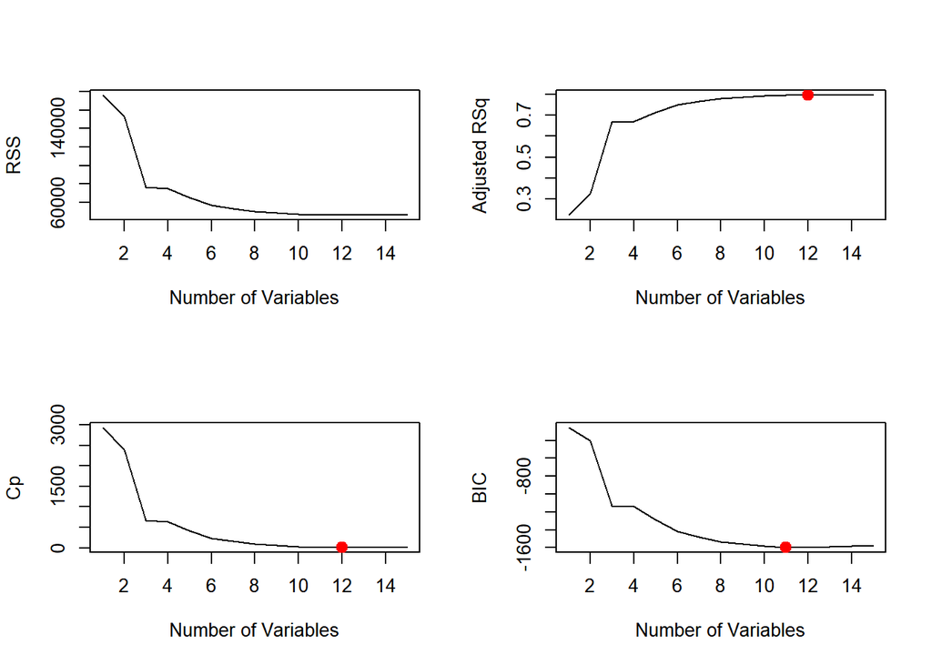

```r
par(mfrow=c(1,1))
```

- 전체적으로 변수의 개수가 11~13일 때 안정화되는 경향이 있다.
- 분석결과 $R_{adj}^2$와 $Cp$는 변수의 개수 12인 모형, 그리고 $BIC$의 경우는 변수의 개수 11인 모형을 최적으로 판단하고 있다.

#### 교차타당검증에 의한 모형 비교

- 지금부터는 train:test=7:3 으로 데이터를 나누어서 몇 개의 후보 모형들의 test RMSE를 계산하여 보겠다. 이 값이 작을수록 예측력이 우수한 모형이라고 볼 수 있다.
- 먼저 데이터를 임의로 train:test=7:3 의 비율로 나눈다. train data는 모형구축 시, test data는 구축된 모형을 평가 시 사용한다.
- 모형에 대한 성능은 test RMSE와 SSE/SST를 바탕으로 실시하며, 두가지 기준 모두 그 값이 작을수록 모형의 예측력이 우수하다고 판단하면 된다.
- $RMSE=\sqrt{{\frac {1}{n} \sum_{i=1}^{n} (y_{i}-\hat{y_{i}})^{2}}}$
- $SSE/SST=\frac {\sum_{i=1}^{n} (y_{i}-\hat{y_{i}})^{2}} {\sum_{i=1}^{n} (y_{i}-\bar{y})^{2}}$

```r
set.seed(5790)
train.index <- sample(1:nrow(plantyes), round(nrow(plantyes)*7/10), replace=F)
ex1_train <- plantyes[train.index,]
ex1_test <- plantyes[-train.index,]
```

```r
# model1 : 모든 주효과 및 교호작용을 포함한 모형
m0 <- lm(내부CO2~(외부기온+외부CO2+외부풍속+외부일사량+환기창면적)^2,data=ex1_train)
y_hat0 <- predict(m0,ex1_test)
RMSE0 <- sqrt(mean((ex1_test$내부CO2-y_hat0)^2))
SSE0 <- sum((ex1_test$내부CO2-y_hat0)^2)
SST0 <- sum((ex1_test$내부CO2-mean(ex1_test$내부CO2))^2)
result0 <- data.frame(ex1_test$내부CO2, y_hat0, ex1_test$내부CO2-y_hat0)
colnames(result0) <- c('y','yhat','y-yhat')
RMSE0 # test RMSE
```

```
## [1] 8.175091
```

```r
SSE0/SST0 # SSE/SST
```

```
## [1] 0.3440289
```

```r
head(result0,12)
```

```
##        y     yhat    y-yhat
## 3  451.3 448.1688  3.131206
## 5  441.7 438.4265  3.273451
## 10 436.3 433.3453  2.954734
## 12 434.0 431.9512  2.048793
## 17 427.7 425.6763  2.023678
## 20 424.0 422.0132  1.986797
## 23 423.3 420.7597  2.540330
## 24 418.7 418.8434 -0.143408
## 33 422.7 424.0400 -1.340006
## 39 419.7 417.8861  1.813880
## 45 415.3 406.6805  8.619452
## 54 502.7 475.7846 26.915421
```

```r
# model2 : Adj R^2, Cp, BIC에 의하여 선택된 모형
m0 <- lm(내부CO2~외부CO2+외부풍속+환기창면적+외부기온*외부CO2+외부기온*외부풍속+외부기온*외부일사량+외부기온*환기창면적+외부CO2*외부풍속+외부CO2*외부일사량+외부CO2*환기창면적+외부풍속*외부일사량+외부풍속*환기창면적,data=ex1_train)
y_hat0 <- predict(m0,ex1_test)
RMSE1 <- sqrt(mean((ex1_test$내부CO2-y_hat0)^2))
SSE1 <- sum((ex1_test$내부CO2-y_hat0)^2)
SST1 <- sum((ex1_test$내부CO2-mean(ex1_test$내부CO2))^2)
result1 <- data.frame(ex1_test$내부CO2, y_hat0, ex1_test$내부CO2-y_hat0)
colnames(result1) <- c('y','yhat','y-yhat')
RMSE1 # test RMSE
```

```
## [1] 8.175741
```

```r
SSE1/SST1 # SSE/SST
```

```
## [1] 0.3440836
```

```r
head(result1,12)
```

```
##        y     yhat     y-yhat
## 3  451.3 448.2007  3.0992956
## 5  441.7 438.4309  3.2691271
## 10 436.3 433.3218  2.9781636
## 12 434.0 431.9115  2.0884767
## 17 427.7 425.6970  2.0030310
## 20 424.0 422.0227  1.9772540
## 23 423.3 420.8268  2.4731625
## 24 418.7 418.8591 -0.1591382
## 33 422.7 423.9709 -1.2708502
## 39 419.7 417.8985  1.8014621
## 45 415.3 406.7941  8.5058796
## 54 502.7 475.7861 26.9139373
```

```r
# model3 : 모든 주효과, 그리고 중요한 3개의 교호작용을 포함한 모형
m0 <- lm(내부CO2~외부기온+외부CO2+외부풍속+외부일사량+환기창면적+외부CO2*환기창면적+외부기온*환기창면적+외부기온*외부일사량,data=ex1_train)
y_hat0 <- predict(m0,ex1_test)
RMSE2 <- sqrt(mean((ex1_test$내부CO2-y_hat0)^2))
SSE2 <- sum((ex1_test$내부CO2-y_hat0)^2)
SST2 <- sum((ex1_test$내부CO2-mean(ex1_test$내부CO2))^2)
result2 <- data.frame(ex1_test$내부CO2, y_hat0, ex1_test$내부CO2-y_hat0)
colnames(result2) <- c('y','yhat','y-yhat')
RMSE2 # test RMSE
```

```
## [1] 6.886057
```

```r
SSE2/SST2 # SSE/SST
```

```
## [1] 0.2440905
```

```r
head(result2,12)
```

```
##        y     yhat     y-yhat
## 3  451.3 441.4271  9.8729392
## 5  441.7 434.5006  7.1994397
## 10 436.3 430.7696  5.5304327
## 12 434.0 429.4604  4.5396279
## 17 427.7 423.1425  4.5574508
## 20 424.0 420.1821  3.8178611
## 23 423.3 418.0704  5.2296101
## 24 418.7 418.1118  0.5882125
## 33 422.7 425.9216 -3.2215893
## 39 419.7 418.4016  1.2984044
## 45 415.3 406.9493  8.3506958
## 54 502.7 462.7100 39.9899501
```

```r
# model4 : 모든 주효과, 그리고 외부CO2와 환기창면적과의 교호작용 1개만을 포함한 모형
m0 <- lm(내부CO2~외부기온+외부CO2+외부풍속+외부일사량+환기창면적+외부CO2*환기창면적,data=ex1_train)
y_hat0 <- predict(m0,ex1_test)
RMSE3 <- sqrt(mean((ex1_test$내부CO2-y_hat0)^2))
SSE3 <- sum((ex1_test$내부CO2-y_hat0)^2)
SST3 <- sum((ex1_test$내부CO2-mean(ex1_test$내부CO2))^2)
result3 <- data.frame(ex1_test$내부CO2, y_hat0, ex1_test$내부CO2-y_hat0)
colnames(result3) <- c('y','yhat','y-yhat')
RMSE3 # test RMSE
```

```
## [1] 8.193375
```

```r
SSE3/SST3 # SSE/SST
```

```
## [1] 0.3455695
```

```r
head(result3,12)
```

```
##        y     yhat    y-yhat
## 3  451.3 438.4142 12.885769
## 5  441.7 433.2887  8.411267
## 10 436.3 432.3442  3.955800
## 12 434.0 430.4040  3.595986
## 17 427.7 425.2248  2.475234
## 20 424.0 421.2366  2.763393
## 23 423.3 421.1074  2.192561
## 24 418.7 420.0659 -1.365864
## 33 422.7 417.9101  4.789902
## 39 419.7 417.9105  1.789453
## 45 415.3 414.5704  0.729640
## 54 502.7 451.6489 51.051125
```

```r
# model5 : 모든 주효과, 그리고 외부기온과 환기창면적과의 교호작용 1개만을 포함한 모형
m0 <- lm(내부CO2~외부기온+외부CO2+외부풍속+외부일사량+환기창면적+외부기온*환기창면적,data=ex1_train)
y_hat0 <- predict(m0,ex1_test)
RMSE4 <- sqrt(mean((ex1_test$내부CO2-y_hat0)^2))
SSE4 <- sum((ex1_test$내부CO2-y_hat0)^2)
SST4 <- sum((ex1_test$내부CO2-mean(ex1_test$내부CO2))^2)
result4 <- data.frame(ex1_test$내부CO2, y_hat0, ex1_test$내부CO2-y_hat0)
colnames(result4) <- c('y','yhat','y-yhat')
RMSE4 # test RMSE
```

```
## [1] 11.40215
```

```r
SSE4/SST4 # SSE/SST
```

```
## [1] 0.6692425
```

```r
head(result4,12)
```

```
##        y     yhat    y-yhat
## 3  451.3 432.3180 18.982024
## 5  441.7 427.7182 13.981765
## 10 436.3 427.4727  8.827344
## 12 434.0 427.2013  6.798703
## 17 427.7 422.0216  5.678374
## 20 424.0 420.7565  3.243508
## 23 423.3 419.5063  3.793651
## 24 418.7 417.5481  1.151949
## 33 422.7 415.2824  7.417556
## 39 419.7 414.4545  5.245504
## 45 415.3 411.4634  3.836638
## 54 502.7 438.3132 64.386845
```

```r
# model6 : 모든 주효과, 그리고 외부기온과 외부일사량과의 교호작용 1개만을 포함한 모형
m0 <- lm(내부CO2~외부기온+외부CO2+외부풍속+외부일사량+환기창면적+외부기온*외부일사량,data=ex1_train)
y_hat0 <- predict(m0,ex1_test)
RMSE5 <- sqrt(mean((ex1_test$내부CO2-y_hat0)^2))
SSE5 <- sum((ex1_test$내부CO2-y_hat0)^2)
SST5 <- sum((ex1_test$내부CO2-mean(ex1_test$내부CO2))^2)
result5 <- data.frame(ex1_test$내부CO2, y_hat0, ex1_test$내부CO2-y_hat0)
colnames(result5) <- c('y','yhat','y-yhat')
RMSE5 # test RMSE
```

```
## [1] 10.63139
```

```r
SSE5/SST5 # SSE/SST
```

```
## [1] 0.5818215
```

```r
head(result5,12)
```

```
##        y     yhat     y-yhat
## 3  451.3 432.8355 18.4645214
## 5  441.7 426.8405 14.8594957
## 10 436.3 424.9300 11.3700278
## 12 434.0 425.3025  8.6974684
## 17 427.7 420.1509  7.5490919
## 20 424.0 420.1661  3.8339342
## 23 423.3 417.3659  5.9340790
## 24 418.7 417.2684  1.4315591
## 33 422.7 431.1371 -8.4370549
## 39 419.7 420.3748 -0.6748027
## 45 415.3 405.3694  9.9305748
## 54 502.7 448.8967 53.8033240
```

- 결과적으로 6가지 모형들 중 모든 주효과, 그리고 주요한 3개의 교호작용을 포함한 모형(model3)이 가장 우수하였다.
- `:`표시는 교호작용을 의미함.
- model1 : 모든 주효과 및 교호작용을 포함한 모형
  - 반응변수 : 내부CO2
  - 설명변수 : 외부기온, 외부CO2, 외부풍속, 외부일사량, 환기창면적, 외부기온:외부CO2, 외부기온:외부풍속, 외부기온:외부일사량, 외부기온:환기창면적, 외부CO2:외부풍속, 외부CO2:외부일사량, 외부CO2:환기창면적, 외부풍속:외부일사량, 외부풍속:환기창면적, 외부일사량:환기창면적
  - RMSE=8.1751, SSE/SST=0.3440
- model2 : Adj R^2, Cp, BIC에 의하여 선택된 모형
  - 반응변수 : 내부CO2
  - 설명변수 : 외부CO2, 외부풍속, 환기창면적, 외부기온:외부CO2, 외부기온:외부풍속, 외부기온:외부일사량, 외부기온:환기창면적, 외부CO2:외부풍속, 외부CO2:외부일사량, 외부CO2:환기창면적, 외부풍속:외부일사량, 외부풍속:환기창면적
  - RMSE=8.1757, SSE/SST=0.3441
- model3 : 모든 주효과, 그리고 중요한 3개의 교호작용을 포함한 모형
  - 반응변수 : 내부CO2
  - 설명변수 : 외부기온, 외부CO2, 외부풍속, 외부일사량, 환기창면적, 외부CO2:환기창면적, 외부기온:환기창면적, 외부기온:외부일사량
  - RMSE=6.8861, SSE/SST=0.2441
- model4 : 모든 주효과, 그리고 외부CO2와 환기창면적과의 교호작용 1개만을 포함한 모형
  - 반응변수 : 내부CO2
  - 설명변수 : 외부기온, 외부CO2, 외부풍속, 외부일사량, 환기창면적, 외부CO2:환기창면적
  - RMSE=8.1934, SSE/SST=0.3456
- model5 : 모든 주효과, 그리고 외부기온과 환기창면적과의 교호작용 1개만을 포함한 모형
  - 반응변수 : 내부CO2
  - 설명변수 : 외부기온, 외부CO2, 외부풍속, 외부일사량, 환기창면적, 외부기온:환기창면적
  - RMSE=11.4022, SSE/SST=0.6692
- model6 : 모든 주효과, 그리고 외부기온과 외부일사량과의 교호작용 1개만을 포함한 모형
  - 반응변수 : 내부CO2
  - 설명변수 : 외부기온, 외부CO2, 외부풍속, 외부일사량, 환기창면적, 외부기온:외부일사량
  - RMSE=10.6314, SSE/SST=0.5818

#### 아래는 여섯 모형에 대한 데이터 전체 적합결과이다.

#### 1. model1

```r
summary(lm(내부CO2~(외부기온+외부CO2+외부풍속+외부일사량+환기창면적)^2,data=plantyes) )
```

```
##
## Call:
## lm(formula = 내부CO2 ~ (외부기온 + 외부CO2 + 외부풍속 + 외부일사량 +
##     환기창면적)^2, data = plantyes)
##
## Residuals:
##     Min      1Q  Median      3Q     Max
## -30.431  -3.477  -0.534   2.837  38.516
##
## Coefficients:
##                         Estimate Std. Error t value Pr(>|t|)
## (Intercept)           -5.670e+02  5.570e+01 -10.180  < 2e-16 ***
## 외부기온              -1.489e+00  2.005e+00  -0.742   0.4580
## 외부CO2                2.201e+00  1.242e-01  17.727  < 2e-16 ***
## 외부풍속               3.640e+01  5.802e+00   6.274 5.15e-10 ***
## 외부일사량             2.476e-03  2.566e-02   0.096   0.9231
## 환기창면적             5.790e+03  1.969e+02  29.410  < 2e-16 ***
## 외부기온:외부CO2       1.084e-02  4.661e-03   2.325   0.0203 *
## 외부기온:외부풍속     -4.734e-01  1.057e-01  -4.477 8.40e-06 ***
## 외부기온:외부일사량    3.985e-03  3.801e-04  10.484  < 2e-16 ***
## 외부기온:환기창면적   -3.153e+01  2.720e+00 -11.594  < 2e-16 ***
## 외부CO2:외부풍속      -4.456e-02  9.322e-03  -4.780 2.00e-06 ***
## 외부CO2:외부일사량    -2.756e-04  4.796e-05  -5.747 1.19e-08 ***
## 외부CO2:환기창면적    -1.200e+01  3.767e-01 -31.860  < 2e-16 ***
## 외부풍속:외부일사량    2.322e-03  1.178e-03   1.971   0.0490 *
## 외부풍속:환기창면적   -5.178e+01  7.194e+00  -7.197 1.18e-12 ***
## 외부일사량:환기창면적  1.392e-02  3.303e-02   0.421   0.6735
## ---
## Signif. codes:  0 '***' 0.001 '**' 0.01 '*' 0.05 '.' 0.1 ' ' 1
##
## Residual standard error: 6.657 on 1039 degrees of freedom
## Multiple R-squared:  0.7979, Adjusted R-squared:  0.795
## F-statistic: 273.5 on 15 and 1039 DF,  p-value: < 2.2e-16
```

#### 2. model2

```r
summary(lm(내부CO2~외부CO2+외부풍속+환기창면적+외부기온*외부CO2+외부기온*외부풍속+외부기온*외부일사량+외부기온*환기창면적+외부CO2*외부풍속+외부CO2*외부일사량+외부CO2*환기창면적+외부풍속*외부일사량+외부풍속*환기창면적,data=plantyes) )
```

```
##
## Call:
## lm(formula = 내부CO2 ~ 외부CO2 + 외부풍속 + 환기창면적 + 외부기온 *
##     외부CO2 + 외부기온 * 외부풍속 + 외부기온 * 외부일사량 + 외부기온 *
##     환기창면적 + 외부CO2 * 외부풍속 + 외부CO2 * 외부일사량 +
##     외부CO2 * 환기창면적 + 외부풍속 * 외부일사량 + 외부풍속 *
##     환기창면적, data = plantyes)
##
## Residuals:
##     Min      1Q  Median      3Q     Max
## -30.455  -3.496  -0.556   2.848  38.545
##
## Coefficients:
##                       Estimate Std. Error t value Pr(>|t|)
## (Intercept)         -5.652e+02  5.552e+01 -10.181  < 2e-16 ***
## 외부CO2              2.198e+00  1.239e-01  17.744  < 2e-16 ***
## 외부풍속             3.638e+01  5.799e+00   6.273 5.17e-10 ***
## 환기창면적           5.778e+03  1.948e+02  29.664  < 2e-16 ***
## 외부기온            -1.537e+00  2.001e+00  -0.768   0.4426
## 외부일사량           4.094e-03  2.536e-02   0.161   0.8718
## 외부CO2:외부기온     1.084e-02  4.660e-03   2.327   0.0202 *
## 외부풍속:외부기온   -4.740e-01  1.057e-01  -4.485 8.11e-06 ***
## 외부기온:외부일사량  3.980e-03  3.798e-04  10.480  < 2e-16 ***
## 환기창면적:외부기온 -3.114e+01  2.554e+00 -12.191  < 2e-16 ***
## 외부CO2:외부풍속    -4.454e-02  9.318e-03  -4.780 2.01e-06 ***
## 외부CO2:외부일사량  -2.751e-04  4.792e-05  -5.740 1.24e-08 ***
## 외부CO2:환기창면적  -1.198e+01  3.735e-01 -32.082  < 2e-16 ***
## 외부풍속:외부일사량  2.411e-03  1.159e-03   2.080   0.0377 *
## 외부풍속:환기창면적 -5.198e+01  7.176e+00  -7.243 8.52e-13 ***
## ---
## Signif. codes:  0 '***' 0.001 '**' 0.01 '*' 0.05 '.' 0.1 ' ' 1
##
## Residual standard error: 6.655 on 1040 degrees of freedom
## Multiple R-squared:  0.7979, Adjusted R-squared:  0.7952
## F-statistic: 293.3 on 14 and 1040 DF,  p-value: < 2.2e-16
```

#### 3. model3

```r
summary(lm(내부CO2~외부기온+외부CO2+외부풍속+외부일사량+환기창면적+외부CO2*환기창면적+외부기온*환기창면적+외부기온*외부일사량,data=plantyes) )
```

```
##
## Call:
## lm(formula = 내부CO2 ~ 외부기온 + 외부CO2 + 외부풍속 + 외부일사량 +
##     환기창면적 + 외부CO2 * 환기창면적 + 외부기온 * 환기창면적 +
##     외부기온 * 외부일사량, data = plantyes)
##
## Residuals:
##     Min      1Q  Median      3Q     Max
## -25.134  -4.228  -0.769   3.331  40.822
##
## Coefficients:
##                       Estimate Std. Error t value Pr(>|t|)
## (Intercept)         -6.312e+02  2.940e+01 -21.466  < 2e-16 ***
## 외부기온             2.515e+00  4.101e-01   6.131 1.23e-09 ***
## 외부CO2              2.407e+00  5.585e-02  43.096  < 2e-16 ***
## 외부풍속            -1.570e+00  2.529e-01  -6.209 7.67e-10 ***
## 외부일사량          -1.325e-01  9.983e-03 -13.269  < 2e-16 ***
## 환기창면적           6.340e+03  1.819e+02  34.861  < 2e-16 ***
## 외부CO2:환기창면적  -1.322e+01  3.374e-01 -39.168  < 2e-16 ***
## 외부기온:환기창면적 -3.600e+01  2.681e+00 -13.424  < 2e-16 ***
## 외부기온:외부일사량  5.018e-03  3.715e-04  13.509  < 2e-16 ***
## ---
## Signif. codes:  0 '***' 0.001 '**' 0.01 '*' 0.05 '.' 0.1 ' ' 1
##
## Residual standard error: 7.176 on 1046 degrees of freedom
## Multiple R-squared:  0.7636, Adjusted R-squared:  0.7618
## F-statistic: 422.3 on 8 and 1046 DF,  p-value: < 2.2e-16
```

#### 4. model4

```r
summary(lm(내부CO2~외부기온+외부CO2+외부풍속+외부일사량+환기창면적+외부CO2*환기창면적,data=plantyes) )
```

```
##
## Call:
## lm(formula = 내부CO2 ~ 외부기온 + 외부CO2 + 외부풍속 + 외부일사량 +
##     환기창면적 + 외부CO2 * 환기창면적, data = plantyes)
##
## Residuals:
##     Min      1Q  Median      3Q     Max
## -26.129  -4.500  -0.417   3.691  53.565
##
## Coefficients:
##                      Estimate Std. Error t value Pr(>|t|)
## (Intercept)        -4.839e+02  2.649e+01 -18.267   <2e-16 ***
## 외부기온            2.616e-01  1.120e-01   2.335   0.0197 *
## 외부CO2             2.211e+00  6.163e-02  35.870   <2e-16 ***
## 외부풍속           -7.349e-01  2.934e-01  -2.505   0.0124 *
## 외부일사량         -9.756e-04  1.353e-03  -0.721   0.4709
## 환기창면적          4.742e+03  1.515e+02  31.295   <2e-16 ***
## 외부CO2:환기창면적 -1.175e+01  3.657e-01 -32.140   <2e-16 ***
## ---
## Signif. codes:  0 '***' 0.001 '**' 0.01 '*' 0.05 '.' 0.1 ' ' 1
##
## Residual standard error: 8.47 on 1048 degrees of freedom
## Multiple R-squared:   0.67,  Adjusted R-squared:  0.6682
## F-statistic: 354.7 on 6 and 1048 DF,  p-value: < 2.2e-16
```

#### 5. model5

```r
summary(lm(내부CO2~외부기온+외부CO2+외부풍속+외부일사량+환기창면적+외부기온*환기창면적,data=plantyes) )
```

```
##
## Call:
## lm(formula = 내부CO2 ~ 외부기온 + 외부CO2 + 외부풍속 + 외부일사량 +
##     환기창면적 + 외부기온 * 환기창면적, data = plantyes)
##
## Residuals:
##     Min      1Q  Median      3Q     Max
## -65.962  -6.383  -0.703   5.025  64.756
##
## Coefficients:
##                       Estimate Std. Error t value Pr(>|t|)
## (Intercept)          3.476e+02  1.508e+01  23.055  < 2e-16 ***
## 외부기온            -6.995e-01  5.274e-01  -1.326   0.1850
## 외부CO2              2.634e-01  1.613e-02  16.330  < 2e-16 ***
## 외부풍속            -2.411e+00  4.183e-01  -5.763 1.08e-08 ***
## 외부일사량           3.334e-03  1.924e-03   1.733   0.0834 .
## 환기창면적          -1.548e+02  1.131e+02  -1.368   0.1716
## 외부기온:환기창면적  1.207e+00  4.087e+00   0.295   0.7677
## ---
## Signif. codes:  0 '***' 0.001 '**' 0.01 '*' 0.05 '.' 0.1 ' ' 1
##
## Residual standard error: 11.94 on 1048 degrees of freedom
## Multiple R-squared:  0.3449, Adjusted R-squared:  0.3411
## F-statistic: 91.95 on 6 and 1048 DF,  p-value: < 2.2e-16
```

#### 6. model6

```r
summary(lm(내부CO2~외부기온+외부CO2+외부풍속+외부일사량+환기창면적+외부기온*외부일사량,data=plantyes) )
```

```
##
## Call:
## lm(formula = 내부CO2 ~ 외부기온 + 외부CO2 + 외부풍속 + 외부일사량 +
##     환기창면적 + 외부기온 * 외부일사량, data = plantyes)
##
## Residuals:
##     Min      1Q  Median      3Q     Max
## -60.820  -6.473  -0.403   4.778  53.486
##
## Coefficients:
##                       Estimate Std. Error t value Pr(>|t|)
## (Intercept)          4.275e+02  1.107e+01  38.638  < 2e-16 ***
## 외부기온            -3.529e+00  3.010e-01 -11.723  < 2e-16 ***
## 외부CO2              2.479e-01  1.481e-02  16.737  < 2e-16 ***
## 외부풍속            -2.675e+00  3.844e-01  -6.959 6.04e-12 ***
## 외부일사량          -1.705e-01  1.550e-02 -10.998  < 2e-16 ***
## 환기창면적          -1.208e+02  1.040e+01 -11.616  < 2e-16 ***
## 외부기온:외부일사량  6.524e-03  5.776e-04  11.294  < 2e-16 ***
## ---
## Signif. codes:  0 '***' 0.001 '**' 0.01 '*' 0.05 '.' 0.1 ' ' 1
##
## Residual standard error: 11.27 on 1048 degrees of freedom
## Multiple R-squared:  0.4159, Adjusted R-squared:  0.4126
## F-statistic: 124.4 on 6 and 1048 DF,  p-value: < 2.2e-16
```

#### 해석

- 외부CO2는 양의 연관성을 내부CO2와 가지는 것으로 보인다.

### 2.3 작물유무 데이터를 합친 경우

#### Multiple Linear Regression Model

```r
m_total <- lm(내부CO2~외부기온+외부CO2+외부풍속+외부일사량+환기창면적+작물유무+외부CO2*환기창면적+외부기온*외부일사량+외부기온*환기창면적+작물유무*외부기온+작물유무*외부CO2+작물유무*외부풍속+작물유무*외부일사량+작물유무*환기창면적,data=plant)
summary(m_total)
```

```
##
## Call:
## lm(formula = 내부CO2 ~ 외부기온 + 외부CO2 + 외부풍속 + 외부일사량 +
##     환기창면적 + 작물유무 + 외부CO2 * 환기창면적 + 외부기온 *
##     외부일사량 + 외부기온 * 환기창면적 + 작물유무 * 외부기온 +
##     작물유무 * 외부CO2 + 작물유무 * 외부풍속 + 작물유무 * 외부일사량 +
##     작물유무 * 환기창면적, data = plant)
##
## Residuals:
##     Min      1Q  Median      3Q     Max
## -60.514  -7.380  -1.219   4.496  56.801
##
## Coefficients:
##                          Estimate Std. Error t value Pr(>|t|)
## (Intercept)             4.355e+01  5.561e+01   0.783  0.43368
## 외부기온               -2.554e-01  6.924e-01  -0.369  0.71225
## 외부CO2                 1.172e+00  9.227e-02  12.700  < 2e-16 ***
## 외부풍속               -2.837e+00  7.125e-01  -3.981 7.13e-05 ***
## 외부일사량             -1.282e-01  1.830e-02  -7.004 3.52e-12 ***
## 환기창면적              5.004e+03  3.952e+02  12.662  < 2e-16 ***
## 작물유무yes            -4.225e+02  4.370e+01  -9.670  < 2e-16 ***
## 외부CO2:환기창면적     -1.014e+01  6.563e-01 -15.452  < 2e-16 ***
## 외부기온:외부일사량     5.165e-03  7.779e-04   6.640 4.15e-11 ***
## 외부기온:환기창면적    -2.482e+01  4.358e+00  -5.696 1.43e-08 ***
## 외부기온:작물유무yes    1.111e+00  4.035e-01   2.755  0.00594 **
## 외부CO2:작물유무yes     7.360e-01  8.556e-02   8.602  < 2e-16 ***
## 외부풍속:작물유무yes    1.084e+00  9.160e-01   1.183  0.23678
## 외부일사량:작물유무yes -7.907e-03  5.399e-03  -1.464  0.14327
## 환기창면적:작물유무yes -2.446e+02  7.436e+01  -3.289  0.00102 **
## ---
## Signif. codes:  0 '***' 0.001 '**' 0.01 '*' 0.05 '.' 0.1 ' ' 1
##
## Residual standard error: 16.47 on 1775 degrees of freedom
## Multiple R-squared:  0.9536, Adjusted R-squared:  0.9532
## F-statistic:  2604 on 14 and 1775 DF,  p-value: < 2.2e-16
```

- 모형적합 결과 외부기온, 외부풍속과 작물유무 사이의 교호작용, 그리고 외부일사량과 작물유무 사이의 교호작용이 유의수준 0.05에서 유의미하지 않다.
- 그리고 가장 중요한 교호작용은 세가지를 선택할 수 있는데 바로 t 통계량의 절대값이 가장 큰 외부CO2와 환기창면적 사이의 교호작용, t 통계량의 절대값이 두번째로 큰 외부CO2와 작물유무 사이의 교호작용, 그리고 t 통계량의 절대값이 세번째로 큰 외부기온과 외부일사량 사이의 교호작용이라고 판단된다.
- 조정된 결정계수의 값은 $R^2_{adj}=0.9532$이다.

#### Best subset selection

- 여러 측도들을 이용하여 모형에 포함될 변수를 적절히 선택해 보도록 하겠다.

```r
library(leaps)
ms0 <- regsubsets(내부CO2~외부기온+외부CO2+외부풍속+외부일사량+환기창면적+작물유무+외부CO2*환기창면적+외부기온*외부일사량+외부기온*환기창면적+작물유무*외부기온+작물유무*외부CO2+작물유무*외부풍속+작물유무*외부일사량+작물유무*환기창면적,data=plant,nvmax=14)
ms0.summary <- summary(ms0)
ms0.summary
```

```
## Subset selection object
## Call: regsubsets.formula(내부CO2 ~ 외부기온 + 외부CO2 + 외부풍속 +
##     외부일사량 + 환기창면적 + 작물유무 + 외부CO2 * 환기창면적 +
##     외부기온 * 외부일사량 + 외부기온 * 환기창면적 + 작물유무 *
##     외부기온 + 작물유무 * 외부CO2 + 작물유무 * 외부풍속 + 작물유무 *
##     외부일사량 + 작물유무 * 환기창면적, data = plant, nvmax = 14)
## 14 Variables  (and intercept)
##                        Forced in Forced out
## 외부기온                   FALSE      FALSE
## 외부CO2                    FALSE      FALSE
## 외부풍속                   FALSE      FALSE
## 외부일사량                 FALSE      FALSE
## 환기창면적                 FALSE      FALSE
## 작물유무yes                FALSE      FALSE
## 외부CO2:환기창면적         FALSE      FALSE
## 외부기온:외부일사량        FALSE      FALSE
## 외부기온:환기창면적        FALSE      FALSE
## 외부기온:작물유무yes       FALSE      FALSE
## 외부CO2:작물유무yes        FALSE      FALSE
## 외부풍속:작물유무yes       FALSE      FALSE
## 외부일사량:작물유무yes     FALSE      FALSE
## 환기창면적:작물유무yes     FALSE      FALSE
## 1 subsets of each size up to 14
## Selection Algorithm: exhaustive
##           외부기온 외부CO2 외부풍속 외부일사량 환기창면적 작물유무yes
## 1  ( 1 )  " "      " "     " "      " "        " "        "*"
## 2  ( 1 )  " "      "*"     " "      " "        " "        " "
## 3  ( 1 )  " "      "*"     " "      " "        "*"        " "
## 4  ( 1 )  " "      "*"     " "      " "        "*"        "*"
## 5  ( 1 )  " "      "*"     " "      " "        "*"        "*"
## 6  ( 1 )  " "      "*"     "*"      " "        "*"        "*"
## 7  ( 1 )  " "      "*"     " "      "*"        "*"        "*"
## 8  ( 1 )  " "      "*"     " "      "*"        "*"        "*"
## 9  ( 1 )  " "      "*"     "*"      "*"        "*"        "*"
## 10  ( 1 ) " "      "*"     "*"      "*"        "*"        "*"
## 11  ( 1 ) " "      "*"     "*"      "*"        "*"        "*"
## 12  ( 1 ) " "      "*"     "*"      "*"        "*"        "*"
## 13  ( 1 ) " "      "*"     "*"      "*"        "*"        "*"
## 14  ( 1 ) "*"      "*"     "*"      "*"        "*"        "*"
##           외부CO2:환기창면적 외부기온:외부일사량 외부기온:환기창면적
```

[output cut: 29 more lines]

```
##           외부일사량:작물유무yes 환기창면적:작물유무yes
## 1  ( 1 )  " "                    " "
## 2  ( 1 )  " "                    " "
## 3  ( 1 )  " "                    " "
## 4  ( 1 )  " "                    " "
## 5  ( 1 )  " "                    " "
## 6  ( 1 )  " "                    " "
## 7  ( 1 )  " "                    " "
## 8  ( 1 )  " "                    " "
## 9  ( 1 )  " "                    " "
## 10  ( 1 ) " "                    "*"
## 11  ( 1 ) " "                    "*"
## 12  ( 1 ) "*"                    "*"
## 13  ( 1 ) "*"                    "*"
## 14  ( 1 ) "*"                    "*"
```

```r
par(mfrow=c(2,2))
# RSS=SSE
plot(ms0.summary$rss,xlab="Number of Variables",ylab="RSS",type="l")
# Adj R^2
plot(ms0.summary$adjr2,xlab="Number of Variables",ylab="Adjusted RSq",type="l")
which.max(ms0.summary$adjr2)
```

```
## [1] 13
```

```r
points(which.max(ms0.summary$adjr2)
,ms0.summary$adjr2[which.max(ms0.summary$adjr2)
], col="red",cex=2,pch=20)
# Cp
plot(ms0.summary$cp,xlab="Number of Variables",ylab="Cp",type='l')
which.min(ms0.summary$cp)
```

```
## [1] 12
```

```r
points(which.min(ms0.summary$cp)
,ms0.summary$cp[which.min(ms0.summary$cp)
],col="red",cex=2,pch=20)
# BIC
plot(ms0.summary$bic,xlab="Number of Variables",ylab="BIC",type='l')
which.min(ms0.summary$bic)
```

```
## [1] 10
```

```r
points(which.min(ms0.summary$bic)
,ms0.summary$bic[which.min(ms0.summary$bic)
],col="red",cex=2,pch=20)
```

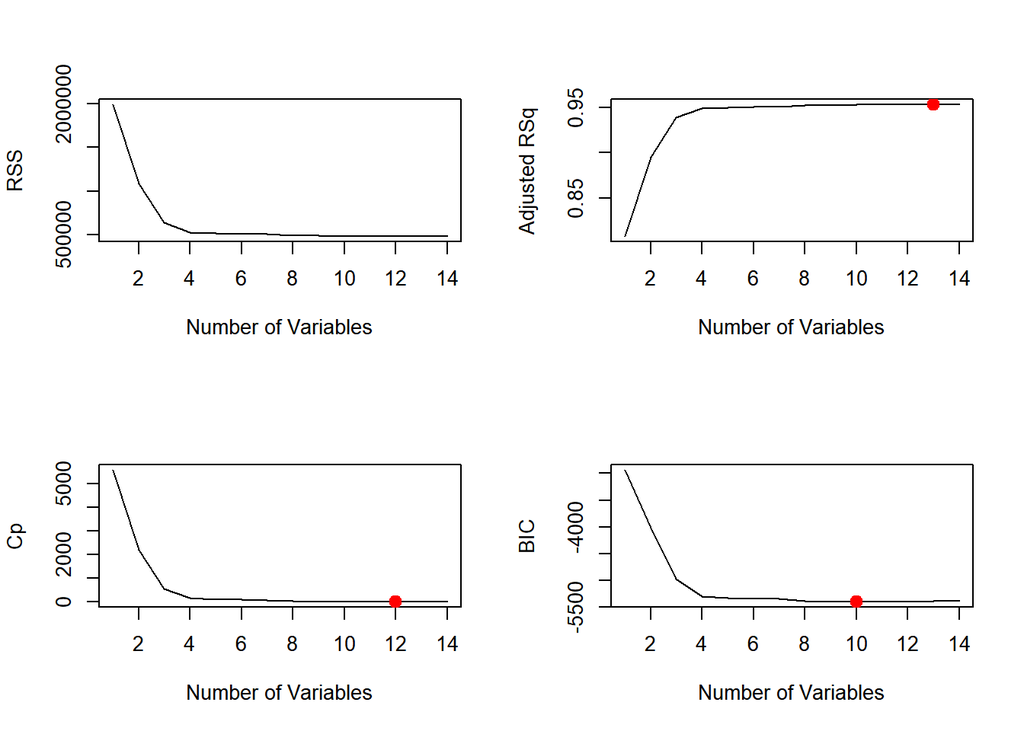

```r
par(mfrow=c(1,1))
```

- 분석결과 $R_{adj}^2$는 변수의 개수 13인 모형, $Cp$는 변수의 개수 12인 모형, 그리고 $BIC$는 변수의 개수 10인 모형을 최적으로 판단하고 있다.

#### 교차타당검증에 의한 모형 비교

- 지금부터는 train:test=7:3 으로 데이터를 나누어서 몇 개의 후보 모형들의 test RMSE를 계산하여 보겠다. 이 값이 작을수록 예측력이 우수한 모형이라고 볼 수 있다.
- 먼저 데이터를 임의로 train:test=7:3 의 비율로 나눈다. train data는 모형구축 시, test data는 구축된 모형을 평가 시 사용한다.
- 모형에 대한 성능은 test RMSE와 SSE/SST를 바탕으로 실시하며, 두가지 기준 모두 그 값이 작을수록 모형의 예측력이 우수하다고 판단하면 된다.
- $RMSE=\sqrt{{\frac {1}{n} \sum_{i=1}^{n} (y_{i}-\hat{y_{i}})^{2}}}$
- $SSE/SST=\frac {\sum_{i=1}^{n} (y_{i}-\hat{y_{i}})^{2}} {\sum_{i=1}^{n} (y_{i}-\bar{y})^{2}}$

```r
set.seed(5790)
train.index <- sample(1:nrow(plant), round(nrow(plant)*7/10), replace=F)
ex1_train <- plant[train.index,]
ex1_test <- plant[-train.index,]
```

```r
# model1 : 최초로 고려한 모형
m0 <- lm(내부CO2~외부기온+외부CO2+외부풍속+외부일사량+환기창면적+작물유무+외부CO2*환기창면적+외부기온*외부일사량+외부기온*환기창면적+작물유무*외부기온+작물유무*외부CO2+작물유무*외부풍속+작물유무*외부일사량+작물유무*환기창면적,data=ex1_train)
y_hat0 <- predict(m0,ex1_test)
RMSE0 <- sqrt(mean((ex1_test$내부CO2-y_hat0)^2))
SSE0 <- sum((ex1_test$내부CO2-y_hat0)^2)
SST0 <- sum((ex1_test$내부CO2-mean(ex1_test$내부CO2))^2)
result0 <- data.frame(ex1_test$내부CO2, y_hat0, ex1_test$내부CO2-y_hat0)
colnames(result0) <- c('y','yhat','y-yhat')
RMSE0 # test RMSE
```

```
## [1] 16.8609
```

```r
SSE0/SST0 # SSE/SST
```

```
## [1] 0.04901901
```

```r
head(result0,12)
```

```
##        y     yhat      y-yhat
## 3  585.5 602.0838 -16.5838240
## 12 573.0 581.4258  -8.4258279
## 15 585.0 596.3995 -11.3995376
## 17 595.5 600.3269  -4.8269189
## 23 582.0 591.1682  -9.1682074
## 24 598.5 603.5085  -5.0085270
## 37 614.5 609.1681   5.3319052
## 39 602.0 606.8428  -4.8427777
## 43 608.5 610.4572  -1.9571925
## 48 608.5 613.9932  -5.4931781
## 51 606.5 612.7058  -6.2057596
## 57 607.0 606.7002   0.2997699
```

```r
# model2 : Adj R^2, Cp, BIC 등의 기준을 바탕으로 선택된 모형 (교호작용이 있는 경우는 주효과 포함)
m0 <- lm(내부CO2~외부CO2+외부풍속+외부일사량+환기창면적+작물유무+외부CO2*환기창면적+외부기온*외부일사량+외부기온*환기창면적+작물유무*외부CO2+작물유무*환기창면적,data=ex1_train)
y_hat0 <- predict(m0,ex1_test)
RMSE1 <- sqrt(mean((ex1_test$내부CO2-y_hat0)^2))
SSE1 <- sum((ex1_test$내부CO2-y_hat0)^2)
SST1 <- sum((ex1_test$내부CO2-mean(ex1_test$내부CO2))^2)
result1 <- data.frame(ex1_test$내부CO2, y_hat0, ex1_test$내부CO2-y_hat0)
colnames(result1) <- c('y','yhat','y-yhat')
RMSE1 # test RMSE
```

```
## [1] 16.81823
```

```r
SSE1/SST1 # SSE/SST
```

```
## [1] 0.04877119
```

```r
head(result1,12)
```

```
##        y     yhat     y-yhat
## 3  585.5 597.4976 -11.997573
## 12 573.0 578.8389  -5.838922
## 15 585.0 597.8089 -12.808872
## 17 595.5 601.4808  -5.980788
## 23 582.0 588.8988  -6.898762
## 24 598.5 604.0440  -5.544019
## 37 614.5 609.2693   5.230715
## 39 602.0 607.2807  -5.280654
## 43 608.5 611.4409  -2.940887
## 48 608.5 614.7443  -6.244331
## 51 606.5 608.9610  -2.461045
## 57 607.0 603.2720   3.727987
```

```r
# model3 : 모든 주효과와 가장 중요한 교호작용 1가지(외부CO2와 환기창면적)를 포함한 모형
m0 <- lm(내부CO2~외부기온+외부CO2+외부풍속+외부일사량+환기창면적+작물유무+외부CO2*환기창면적,data=ex1_train)
y_hat0 <- predict(m0,ex1_test)
RMSE2 <- sqrt(mean((ex1_test$내부CO2-y_hat0)^2))
SSE2 <- sum((ex1_test$내부CO2-y_hat0)^2)
SST2 <- sum((ex1_test$내부CO2-mean(ex1_test$내부CO2))^2)
result2 <- data.frame(ex1_test$내부CO2, y_hat0, ex1_test$내부CO2-y_hat0)
colnames(result2) <- c('y','yhat','y-yhat')
RMSE2 # test RMSE
```

```
## [1] 17.13584
```

```r
SSE2/SST2 # SSE/SST
```

```
## [1] 0.05063065
```

```r
head(result2,12)
```

```
##        y     yhat     y-yhat
## 3  585.5 601.8149 -16.314906
## 12 573.0 585.3398 -12.339835
## 15 585.0 612.5849 -27.584946
## 17 595.5 615.7612 -20.261216
## 23 582.0 587.0200  -5.019974
## 24 598.5 608.7817 -10.281673
## 37 614.5 609.2733   5.226655
## 39 602.0 607.4004  -5.400385
## 43 608.5 613.5988  -5.098793
## 48 608.5 613.8670  -5.367007
## 51 606.5 613.8282  -7.328195
## 57 607.0 609.9709  -2.970868
```

```r
# model4 : 모든 주효과와 가장 중요한 교호작용 2가지(외부CO2와 환기창면적, 외부CO2와 작물유무)를 포함한 모형
m0 <- lm(내부CO2~외부기온+외부CO2+외부풍속+외부일사량+환기창면적+작물유무+외부CO2*환기창면적+외부CO2*작물유무,data=ex1_train)
y_hat0 <- predict(m0,ex1_test)
RMSE3 <- sqrt(mean((ex1_test$내부CO2-y_hat0)^2))
SSE3 <- sum((ex1_test$내부CO2-y_hat0)^2)
SST3 <- sum((ex1_test$내부CO2-mean(ex1_test$내부CO2))^2)
result3 <- data.frame(ex1_test$내부CO2, y_hat0, ex1_test$내부CO2-y_hat0)
colnames(result3) <- c('y','yhat','y-yhat')
RMSE3 # test RMSE
```

```
## [1] 17.01187
```

```r
SSE3/SST3 # SSE/SST
```

```
## [1] 0.04990072
```

```r
head(result3,12)
```

```
##        y     yhat     y-yhat
## 3  585.5 607.8431 -22.343127
## 12 573.0 594.1766 -21.176626
## 15 585.0 607.6058 -22.605753
## 17 595.5 610.1908 -14.690825
## 23 582.0 596.0487 -14.048701
## 24 598.5 607.2155  -8.715545
## 37 614.5 609.5420   4.958025
## 39 602.0 607.9531  -5.953148
## 43 608.5 611.5024  -3.002404
## 48 608.5 612.5781  -4.078052
## 51 606.5 615.3740  -8.874024
## 57 607.0 612.5435  -5.543546
```

- 결과적으로 4가지 모형들 중 Adj R^2, Cp, BIC 등의 기준을 바탕으로 선택된 모형이 가장 우수하였다. 하지만, 오차비율의 차이가 1% 미만이므로 가장 단순한 모형을 선택하는 것도 좋아 보인다.
- `:`표시는 교호작용을 의미함.
- model1 : 최초로 고려한 모형
  - 반응변수 : 내부CO2
  - 설명변수 : 외부기온, 외부CO2, 외부풍속, 외부일사량, 환기창면적, 작물유무, 외부CO2:환기창면적, 외부기온:외부일사량, 외부기온:환기창면적, 작물유무:외부기온, 작물유무:외부CO2, 작물유무:외부풍속, 작물유무:외부일사량, 작물유무:환기창면적
  - RMSE=16.8609, SSE/SST=0.0490
- model2 : Adj R^2, Cp, BIC 등의 기준을 바탕으로 선택된 모형 (교호작용이 있는 경우는 주효과 포함)
  - 반응변수 : 내부CO2
  - 설명변수 : 외부CO2, 외부풍속, 외부일사량, 환기창면적, 작물유무, 외부CO2:환기창면적, 외부기온:외부일사량, 외부기온:환기창면적, 작물유무:외부CO2, 작물유무:환기창면적
  - RMSE=16.8182, SSE/SST=0.0488
- model3 : 모든 주효과와 가장 중요한 교호작용 1가지(외부CO2와 환기창면적)를 포함한 모형
  - 반응변수 : 내부CO2
  - 설명변수 : 외부기온, 외부CO2, 외부풍속, 외부일사량, 환기창면적, 작물유무, 외부CO2:환기창면적
  - RMSE=17.1358, SSE/SST=0.0506
- model4 : 모든 주효과와 가장 중요한 교호작용 2가지(외부CO2와 환기창면적, 외부CO2와 작물유무)를 포함한 모형
  - 반응변수 : 내부CO2
  - 설명변수 : 외부기온, 외부CO2, 외부풍속, 외부일사량, 환기창면적, 작물유무, 외부CO2:환기창면적, 외부CO2:작물유무
  - RMSE=17.0119, SSE/SST=0.0499

#### 아래는 네 모형에 대한 데이터 전체 적합결과이다.

#### 1. model1

```r
summary(lm(내부CO2~외부기온+외부CO2+외부풍속+외부일사량+환기창면적+작물유무+외부CO2*환기창면적+외부기온*외부일사량+외부기온*환기창면적+작물유무*외부기온+작물유무*외부CO2+작물유무*외부풍속+작물유무*외부일사량+작물유무*환기창면적,data=plant) )
```

```
##
## Call:
## lm(formula = 내부CO2 ~ 외부기온 + 외부CO2 + 외부풍속 + 외부일사량 +
##     환기창면적 + 작물유무 + 외부CO2 * 환기창면적 + 외부기온 *
##     외부일사량 + 외부기온 * 환기창면적 + 작물유무 * 외부기온 +
##     작물유무 * 외부CO2 + 작물유무 * 외부풍속 + 작물유무 * 외부일사량 +
##     작물유무 * 환기창면적, data = plant)
##
## Residuals:
##     Min      1Q  Median      3Q     Max
## -60.514  -7.380  -1.219   4.496  56.801
##
## Coefficients:
##                          Estimate Std. Error t value Pr(>|t|)
## (Intercept)             4.355e+01  5.561e+01   0.783  0.43368
## 외부기온               -2.554e-01  6.924e-01  -0.369  0.71225
## 외부CO2                 1.172e+00  9.227e-02  12.700  < 2e-16 ***
## 외부풍속               -2.837e+00  7.125e-01  -3.981 7.13e-05 ***
## 외부일사량             -1.282e-01  1.830e-02  -7.004 3.52e-12 ***
## 환기창면적              5.004e+03  3.952e+02  12.662  < 2e-16 ***
## 작물유무yes            -4.225e+02  4.370e+01  -9.670  < 2e-16 ***
## 외부CO2:환기창면적     -1.014e+01  6.563e-01 -15.452  < 2e-16 ***
## 외부기온:외부일사량     5.165e-03  7.779e-04   6.640 4.15e-11 ***
## 외부기온:환기창면적    -2.482e+01  4.358e+00  -5.696 1.43e-08 ***
## 외부기온:작물유무yes    1.111e+00  4.035e-01   2.755  0.00594 **
## 외부CO2:작물유무yes     7.360e-01  8.556e-02   8.602  < 2e-16 ***
## 외부풍속:작물유무yes    1.084e+00  9.160e-01   1.183  0.23678
## 외부일사량:작물유무yes -7.907e-03  5.399e-03  -1.464  0.14327
## 환기창면적:작물유무yes -2.446e+02  7.436e+01  -3.289  0.00102 **
## ---
## Signif. codes:  0 '***' 0.001 '**' 0.01 '*' 0.05 '.' 0.1 ' ' 1
##
## Residual standard error: 16.47 on 1775 degrees of freedom
## Multiple R-squared:  0.9536, Adjusted R-squared:  0.9532
## F-statistic:  2604 on 14 and 1775 DF,  p-value: < 2.2e-16
```

#### 2. model2

```r
summary(lm(내부CO2~외부CO2+외부풍속+외부일사량+환기창면적+작물유무+외부CO2*환기창면적+외부기온*외부일사량+외부기온*환기창면적+작물유무*외부CO2+작물유무*환기창면적,data=plant) )
```

```
##
## Call:
## lm(formula = 내부CO2 ~ 외부CO2 + 외부풍속 + 외부일사량 + 환기창면적 +
##     작물유무 + 외부CO2 * 환기창면적 + 외부기온 * 외부일사량 +
##     외부기온 * 환기창면적 + 작물유무 * 외부CO2 + 작물유무 * 환기창면적,
##     data = plant)
##
## Residuals:
##     Min      1Q  Median      3Q     Max
## -60.152  -7.962  -1.146   4.660  57.963
##
## Coefficients:
##                          Estimate Std. Error t value Pr(>|t|)
## (Intercept)             1.366e+01  5.326e+01   0.257  0.79757
## 외부CO2                 1.205e+00  8.891e-02  13.556  < 2e-16 ***
## 외부풍속               -2.179e+00  4.467e-01  -4.878 1.17e-06 ***
## 외부일사량             -1.208e-01  1.700e-02  -7.107 1.71e-12 ***
## 환기창면적              4.673e+03  3.742e+02  12.487  < 2e-16 ***
## 작물유무yes            -3.416e+02  3.432e+01  -9.953  < 2e-16 ***
## 외부기온                2.869e-01  6.048e-01   0.474  0.63523
## 외부CO2:환기창면적     -9.674e+00  6.354e-01 -15.225  < 2e-16 ***
## 외부일사량:외부기온     4.681e-03  6.620e-04   7.072 2.19e-12 ***
## 환기창면적:외부기온    -2.123e+01  3.958e+00  -5.363 9.25e-08 ***
## 외부CO2:작물유무yes     6.162e-01  7.412e-02   8.314  < 2e-16 ***
## 환기창면적:작물유무yes -2.053e+02  7.327e+01  -2.802  0.00513 **
## ---
## Signif. codes:  0 '***' 0.001 '**' 0.01 '*' 0.05 '.' 0.1 ' ' 1
##
## Residual standard error: 16.5 on 1778 degrees of freedom
## Multiple R-squared:  0.9533, Adjusted R-squared:  0.953
## F-statistic:  3299 on 11 and 1778 DF,  p-value: < 2.2e-16
```

#### 3. model3

```r
summary(lm(내부CO2~외부기온+외부CO2+외부풍속+외부일사량+환기창면적+작물유무+외부CO2*환기창면적,data=plant) )
```

```
##
## Call:
## lm(formula = 내부CO2 ~ 외부기온 + 외부CO2 + 외부풍속 + 외부일사량 +
##     환기창면적 + 작물유무 + 외부CO2 * 환기창면적, data = plant)
##
## Residuals:
##     Min      1Q  Median      3Q     Max
## -55.792  -8.232  -1.951   5.819  60.669
##
## Coefficients:
##                      Estimate Std. Error t value Pr(>|t|)
## (Intercept)        -9.022e+01  1.868e+01  -4.830 1.48e-06 ***
## 외부기온            1.009e-01  1.801e-01   0.560   0.5754
## 외부CO2             1.393e+00  3.363e-02  41.434  < 2e-16 ***
## 외부풍속           -8.087e-01  4.234e-01  -1.910   0.0563 .
## 외부일사량         -2.272e-03  2.229e-03  -1.019   0.3083
## 환기창면적          2.799e+03  8.355e+01  33.497  < 2e-16 ***
## 작물유무yes        -5.033e+01  2.700e+00 -18.644  < 2e-16 ***
## 외부CO2:환기창면적 -7.064e+00  1.733e-01 -40.756  < 2e-16 ***
## ---
## Signif. codes:  0 '***' 0.001 '**' 0.01 '*' 0.05 '.' 0.1 ' ' 1
##
## Residual standard error: 17.17 on 1782 degrees of freedom
## Multiple R-squared:  0.9493, Adjusted R-squared:  0.9491
## F-statistic:  4770 on 7 and 1782 DF,  p-value: < 2.2e-16
```

#### 4. model4

```r
summary(lm(내부CO2~외부기온+외부CO2+외부풍속+외부일사량+환기창면적+작물유무+외부CO2*환기창면적+외부CO2*작물유무,data=plant) )
```

```
##
## Call:
## lm(formula = 내부CO2 ~ 외부기온 + 외부CO2 + 외부풍속 + 외부일사량 +
##     환기창면적 + 작물유무 + 외부CO2 * 환기창면적 + 외부CO2 *
##     작물유무, data = plant)
##
## Residuals:
##     Min      1Q  Median      3Q     Max
## -61.697  -8.356  -1.412   5.986  56.431
##
## Coefficients:
##                       Estimate Std. Error t value Pr(>|t|)
## (Intercept)          1.349e+02  3.483e+01   3.873 0.000111 ***
## 외부기온             1.234e-01  1.774e-01   0.696 0.486788
## 외부CO2              9.762e-01  6.404e-02  15.244  < 2e-16 ***
## 외부풍속            -2.115e+00  4.507e-01  -4.693 2.90e-06 ***
## 외부일사량          -2.621e-03  2.195e-03  -1.194 0.232537
## 환기창면적           2.906e+03  8.344e+01  34.825  < 2e-16 ***
## 작물유무yes         -3.097e+02  3.419e+01  -9.060  < 2e-16 ***
## 외부CO2:환기창면적  -7.288e+00  1.731e-01 -42.093  < 2e-16 ***
## 외부CO2:작물유무yes  4.989e-01  6.555e-02   7.611 4.39e-14 ***
## ---
## Signif. codes:  0 '***' 0.001 '**' 0.01 '*' 0.05 '.' 0.1 ' ' 1
##
## Residual standard error: 16.9 on 1781 degrees of freedom
## Multiple R-squared:  0.9509, Adjusted R-squared:  0.9507
## F-statistic:  4315 on 8 and 1781 DF,  p-value: < 2.2e-16
```

#### 해석

- 전체적으로 비슷한 설명력을 보인다.
- 외부CO2와 작물유무와의 교호작용이 양수이므로, 작물이 있으면 외부CO2의 증가가 내부CO2의 증가에 미치는 영향이 확대된다.